# Introduction to R

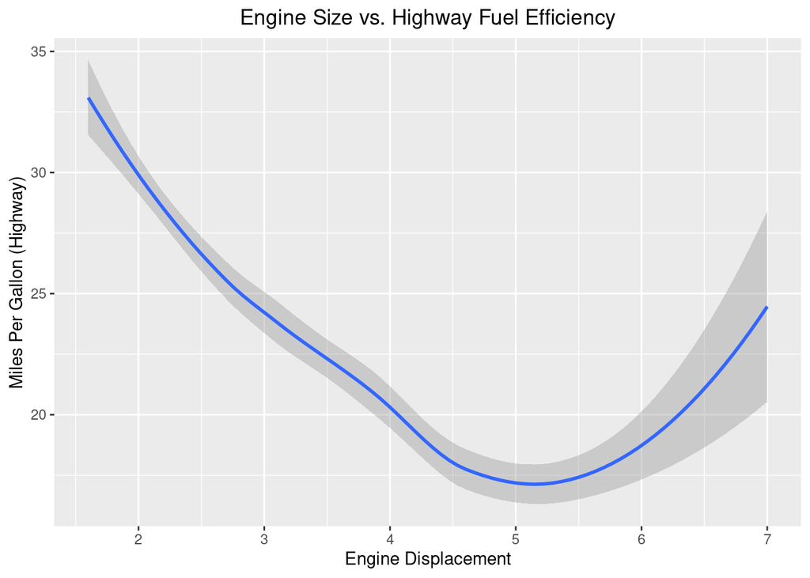

```r
# Just line
ggplot(data = mpg) +
  geom_smooth(mapping = aes(x = displ, y = hwy)) +
    ggtitle("Engine Size vs. Highway Fuel Efficiency") +
             theme(plot.title = element_text(hjust = 0.5)) + # center the title
             xlab("Engine Displacement") +
             ylab("Miles Per Gallon (Highway)")
```

We can also add smoothed lines by different groups. Let’s try this with drive type:

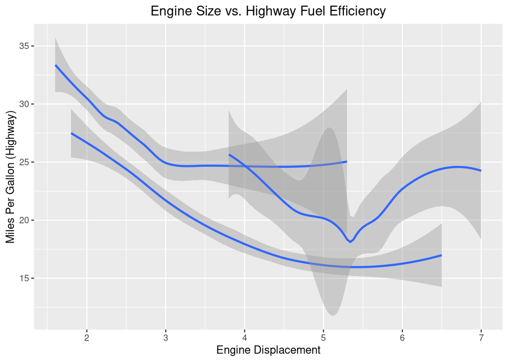

```r
# Just lines
ggplot(data = mpg) +
  geom_smooth(mapping = aes(x = displ, y = hwy, group = drv), show.legend = TRUE) +
    ggtitle("Engine Size vs. Highway Fuel Efficiency") +
             theme(plot.title = element_text(hjust = 0.5)) + # center the title
             xlab("Engine Displacement") +
             ylab("Miles Per Gallon (Highway)")
```

Keep in mind, these examples barely scratch the surface of the figures you can create with `ggplot2` but for the sake of brevity we must move on to other plot types.

### 4.3.2 Histograms

Still using the the **mpg** data, let’s visualize the distribution of highway fuel efficiency.

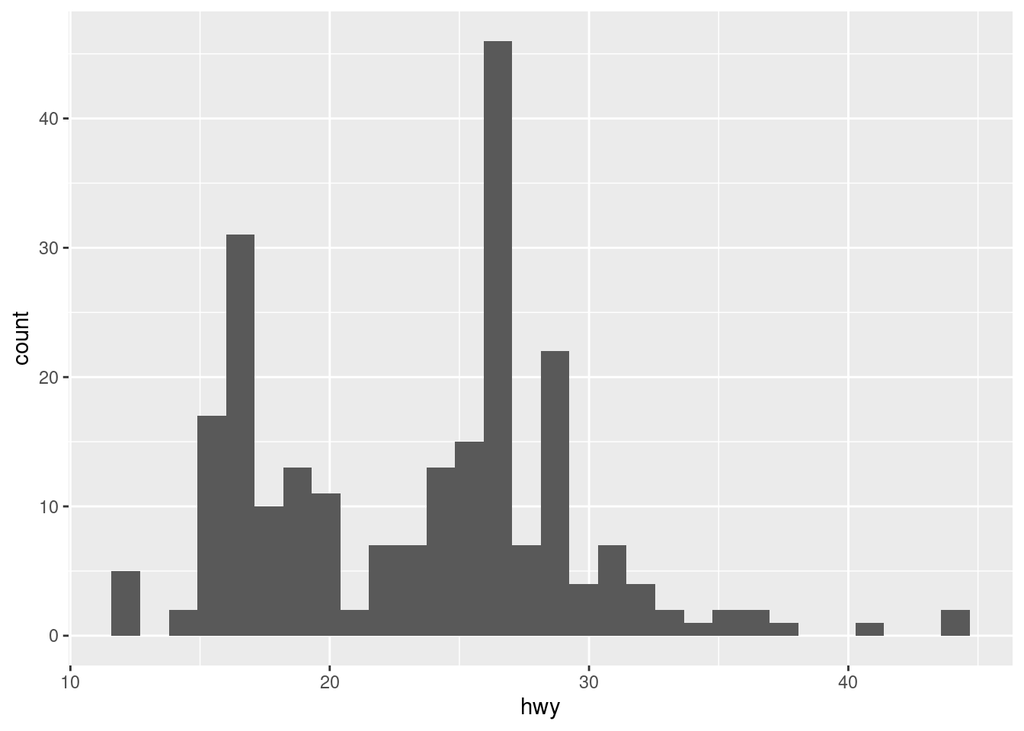

```r
# plain histogram
ggplot(mpg, aes(x=hwy)) + geom_histogram()
```

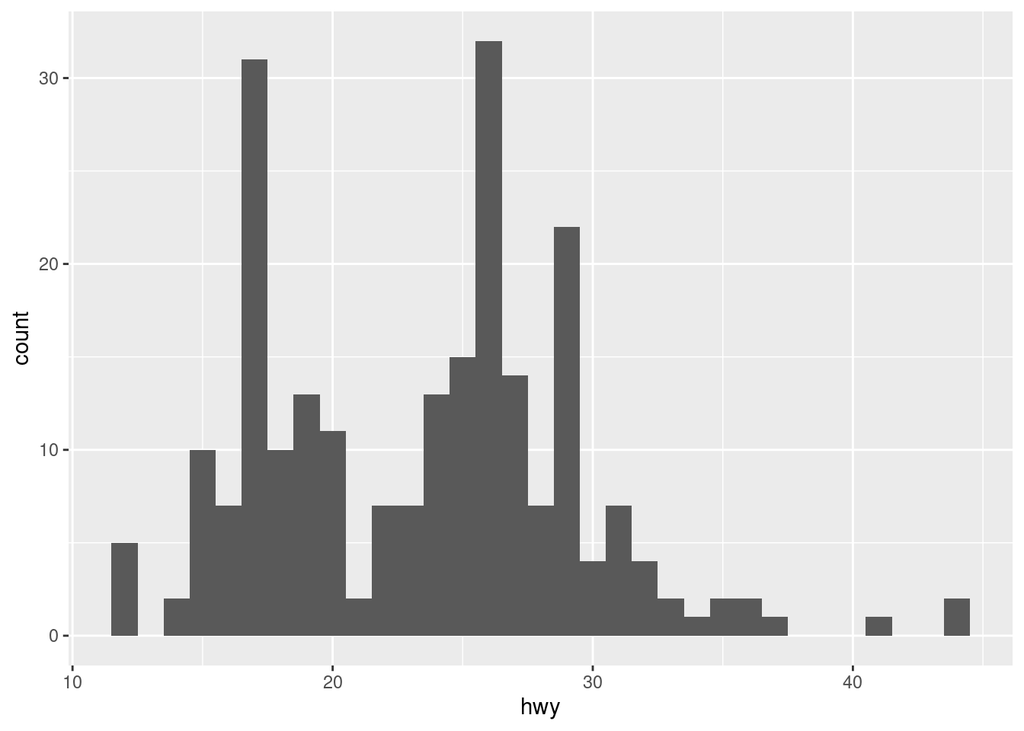

```r
# Change the width of bins
ggplot(mpg, aes(x=hwy)) + geom_histogram(binwidth=1)
```

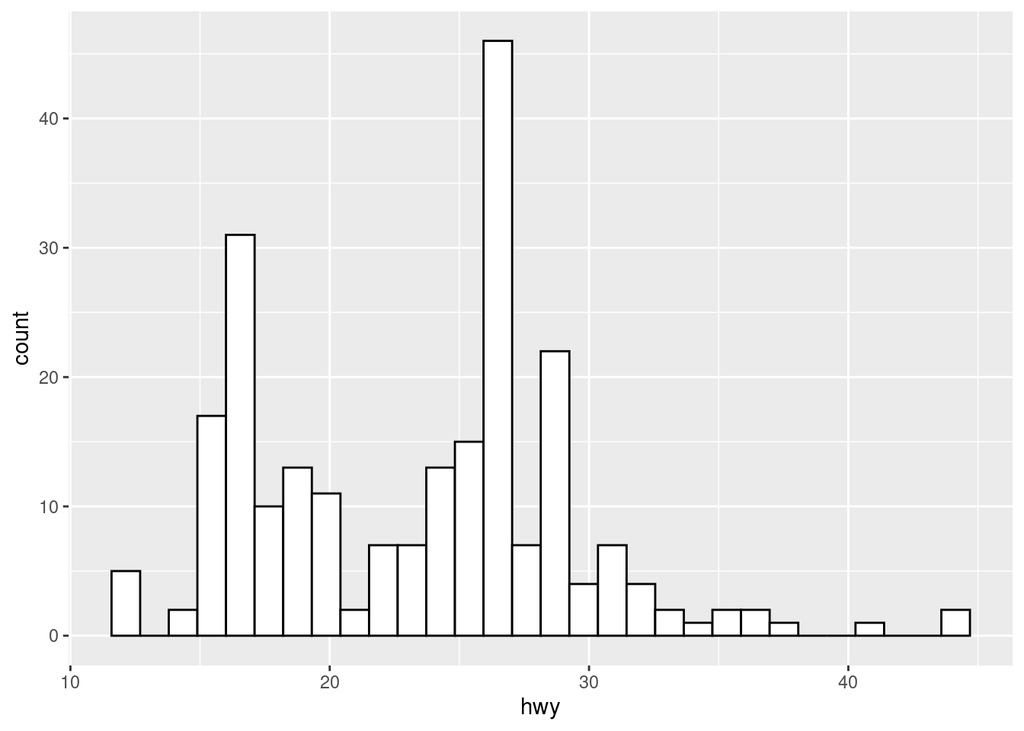

```r
# Change colors
ggplot(mpg, aes(x=hwy)) + geom_histogram(color="black", fill="white")
```

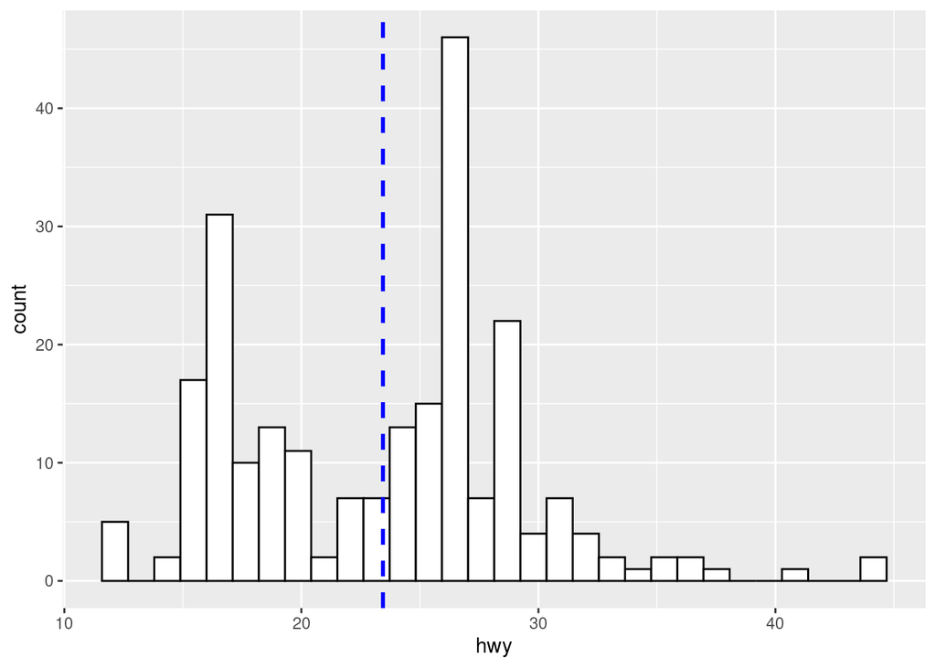

```r
# Add mean line
ggplot(mpg, aes(x=hwy)) +
          geom_histogram(color="black", fill="white") +
          geom_vline(aes(xintercept=mean(hwy)),
                                     color="blue",
                                     linetype="dashed",
                                     size=1)
```

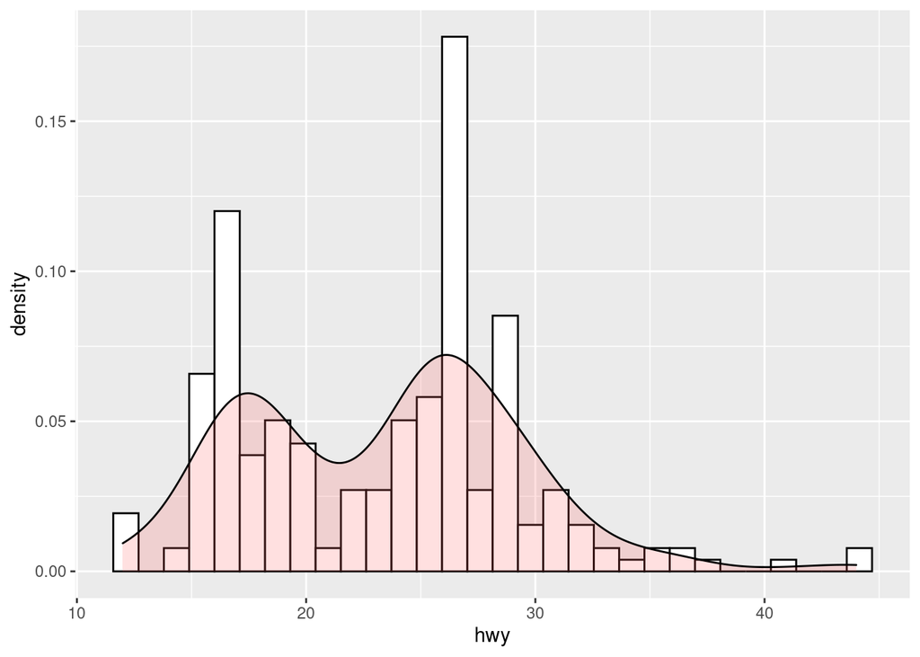

```r
# Histogram with density plot
ggplot(mpg, aes(x=hwy)) +
 geom_histogram(aes(y=..density..), colour="black", fill="white")+
 geom_density(alpha=.2, fill="#FF6666")
```

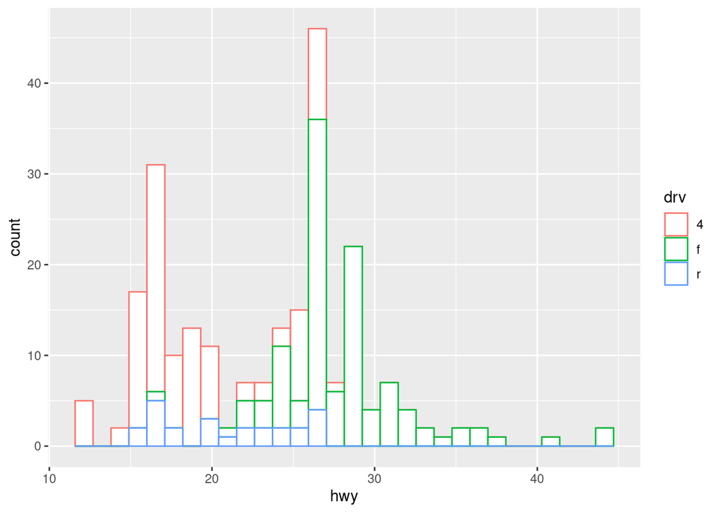

```r
# Change histogram plot line colors by front-, rear-, and four-wheel drive types
ggplot(mpg, aes(x=hwy, color=drv)) + geom_histogram(fill="white")
```

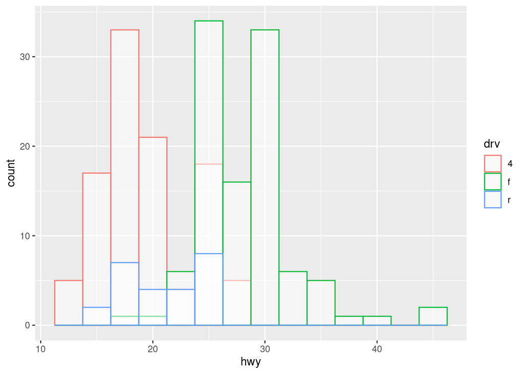

```r
# Overlaid histograms
ggplot(mpg, aes(x=hwy, color=drv)) +
  geom_histogram(fill="white", alpha=0.5, position="identity", binwidth = 2.5)
```

Hopefully, this should give you a good idea of how to create histograms with the `ggplot2` package. If you want to learn more you should definitely try to experiment with the code above.

### 4.3.3 Barplots

In this subsection, let’s shift gears and use the **diamond** data set that comes loaded with `ggplot2`. The **diamonds** data set contains information about the prices and characteristics of diamonds. Let’s start by creating a bar chart that displays the number of diamonds available by diamond quality.

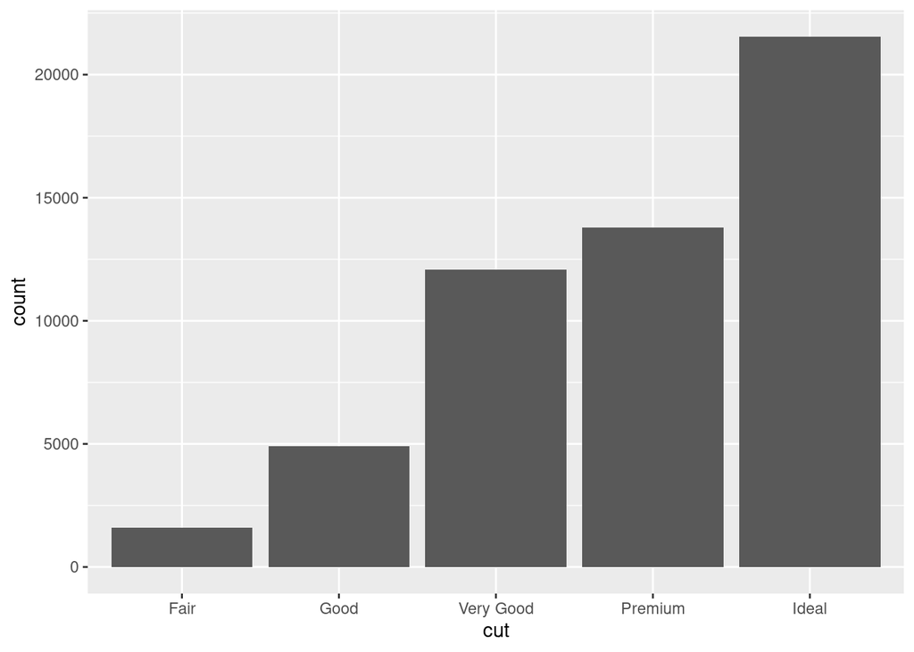

```r
ggplot(data = diamonds) +
  geom_bar(mapping = aes(x = cut))
```

We can further customize this plot by doing

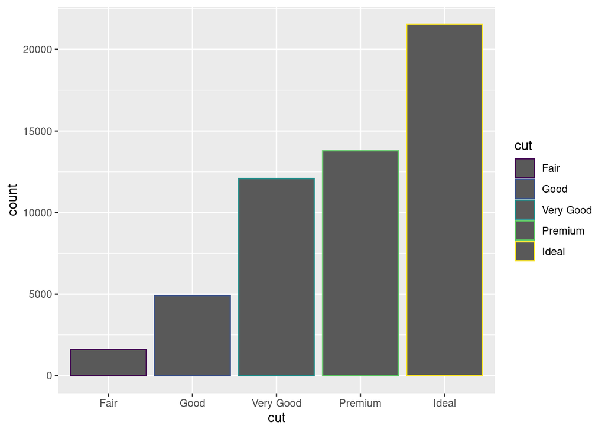

```r
# different exeterior colors
ggplot(data = diamonds) +
  geom_bar(mapping = aes(x = cut, colour = cut))
```

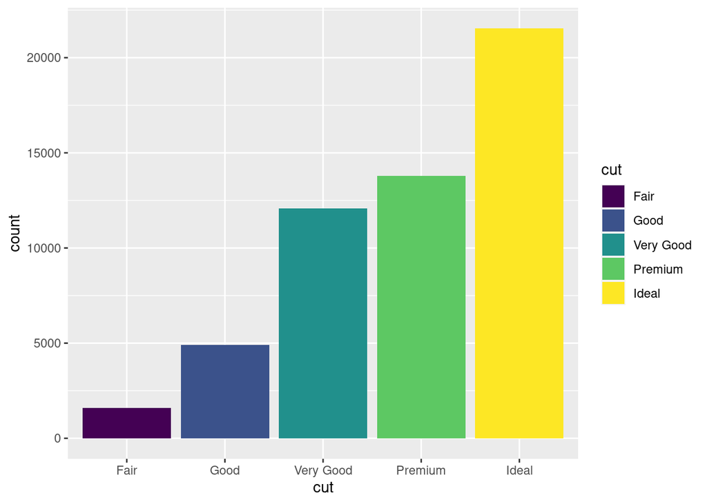

```r
# different fill colors
ggplot(data = diamonds) +
  geom_bar(mapping = aes(x = cut, fill = cut))
```

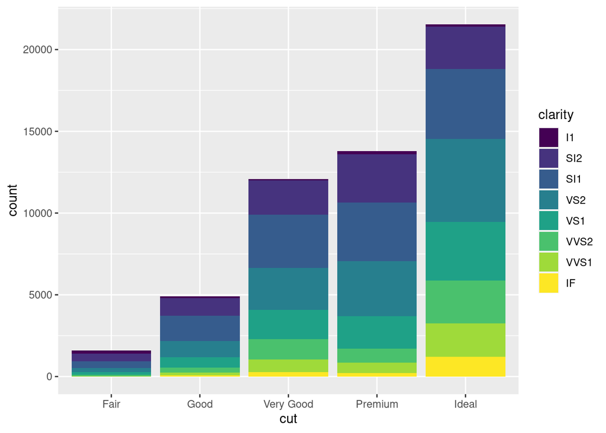

```r
# incorporating more info about diamond clarity
ggplot(data = diamonds) +
  geom_bar(mapping = aes(x = cut, fill = clarity))
```

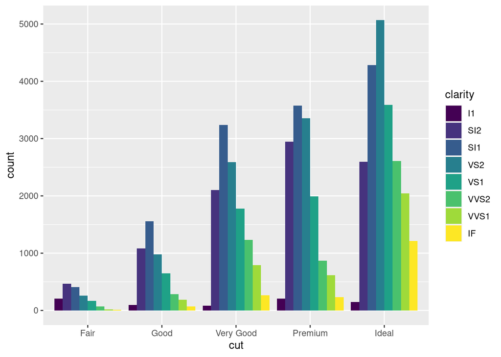

```r
# position = "dodge" places overlapping objects directly beside one another. This makes it easier to compare individual values.
ggplot(data = diamonds) +
  geom_bar(mapping = aes(x = cut, fill = clarity), position = "dodge")
```

# 5 Regression

In this section, I’ll show you how to run basic regressions in R. We’ll start by examining linear regression examples, then we’ll move on to multiple regression with continuous and discrete variables.

## 5.1 Linear regression

Let’s load the `wooldridge` package so we can read in some wage data collected in the 1976 CPS in the US. Naturally, let’s see if there is a relationship between years of education and hourly wages. We’ll treat wages as our outcome variable and years of education as our independent variable.

```r
library(wooldridge) # load package
data("wage1", package = "wooldridge") # read in the data

str(wage1) # getting a feel for the data
```

```
## 'data.frame':    526 obs. of  24 variables:
##  $ wage    : num  3.1 3.24 3 6 5.3 ...
##  $ educ    : int  11 12 11 8 12 16 18 12 12 17 ...
##  $ exper   : int  2 22 2 44 7 9 15 5 26 22 ...
##  $ tenure  : int  0 2 0 28 2 8 7 3 4 21 ...
##  $ nonwhite: int  0 0 0 0 0 0 0 0 0 0 ...
##  $ female  : int  1 1 0 0 0 0 0 1 1 0 ...
##  $ married : int  0 1 0 1 1 1 0 0 0 1 ...
##  $ numdep  : int  2 3 2 0 1 0 0 0 2 0 ...
##  $ smsa    : int  1 1 0 1 0 1 1 1 1 1 ...
##  $ northcen: int  0 0 0 0 0 0 0 0 0 0 ...
##  $ south   : int  0 0 0 0 0 0 0 0 0 0 ...
##  $ west    : int  1 1 1 1 1 1 1 1 1 1 ...
##  $ construc: int  0 0 0 0 0 0 0 0 0 0 ...
##  $ ndurman : int  0 0 0 0 0 0 0 0 0 0 ...
##  $ trcommpu: int  0 0 0 0 0 0 0 0 0 0 ...
##  $ trade   : int  0 0 1 0 0 0 1 0 1 0 ...
##  $ services: int  0 1 0 0 0 0 0 0 0 0 ...
##  $ profserv: int  0 0 0 0 0 1 0 0 0 0 ...
##  $ profocc : int  0 0 0 0 0 1 1 1 1 1 ...
##  $ clerocc : int  0 0 0 1 0 0 0 0 0 0 ...
##  $ servocc : int  0 1 0 0 0 0 0 0 0 0 ...
##  $ lwage   : num  1.13 1.18 1.1 1.79 1.67 ...
##  $ expersq : int  4 484 4 1936 49 81 225 25 676 484 ...
##  $ tenursq : int  0 4 0 784 4 64 49 9 16 441 ...
##  - attr(*, "time.stamp")= chr "25 Jun 2011 23:03"
```

```r
summary(wage1) # summarize the data
```

```
##       wage             educ           exper           tenure
##  Min.   : 0.530   Min.   : 0.00   Min.   : 1.00   Min.   : 0.000
##  1st Qu.: 3.330   1st Qu.:12.00   1st Qu.: 5.00   1st Qu.: 0.000
##  Median : 4.650   Median :12.00   Median :13.50   Median : 2.000
##  Mean   : 5.896   Mean   :12.56   Mean   :17.02   Mean   : 5.105
##  3rd Qu.: 6.880   3rd Qu.:14.00   3rd Qu.:26.00   3rd Qu.: 7.000
##  Max.   :24.980   Max.   :18.00   Max.   :51.00   Max.   :44.000
##     nonwhite          female          married           numdep
##  Min.   :0.0000   Min.   :0.0000   Min.   :0.0000   Min.   :0.000
##  1st Qu.:0.0000   1st Qu.:0.0000   1st Qu.:0.0000   1st Qu.:0.000
##  Median :0.0000   Median :0.0000   Median :1.0000   Median :1.000
##  Mean   :0.1027   Mean   :0.4791   Mean   :0.6084   Mean   :1.044
##  3rd Qu.:0.0000   3rd Qu.:1.0000   3rd Qu.:1.0000   3rd Qu.:2.000
##  Max.   :1.0000   Max.   :1.0000   Max.   :1.0000   Max.   :6.000
##       smsa           northcen         south             west
##  Min.   :0.0000   Min.   :0.000   Min.   :0.0000   Min.   :0.0000
##  1st Qu.:0.0000   1st Qu.:0.000   1st Qu.:0.0000   1st Qu.:0.0000
##  Median :1.0000   Median :0.000   Median :0.0000   Median :0.0000
##  Mean   :0.7224   Mean   :0.251   Mean   :0.3555   Mean   :0.1692
##  3rd Qu.:1.0000   3rd Qu.:0.750   3rd Qu.:1.0000   3rd Qu.:0.0000
##  Max.   :1.0000   Max.   :1.000   Max.   :1.0000   Max.   :1.0000
##     construc          ndurman          trcommpu           trade
##  Min.   :0.00000   Min.   :0.0000   Min.   :0.00000   Min.   :0.0000
##  1st Qu.:0.00000   1st Qu.:0.0000   1st Qu.:0.00000   1st Qu.:0.0000
##  Median :0.00000   Median :0.0000   Median :0.00000   Median :0.0000
##  Mean   :0.04563   Mean   :0.1141   Mean   :0.04373   Mean   :0.2871
##  3rd Qu.:0.00000   3rd Qu.:0.0000   3rd Qu.:0.00000   3rd Qu.:1.0000
##  Max.   :1.00000   Max.   :1.0000   Max.   :1.00000   Max.   :1.0000
##     services         profserv         profocc          clerocc
##  Min.   :0.0000   Min.   :0.0000   Min.   :0.0000   Min.   :0.0000
##  1st Qu.:0.0000   1st Qu.:0.0000   1st Qu.:0.0000   1st Qu.:0.0000
##  Median :0.0000   Median :0.0000   Median :0.0000   Median :0.0000
##  Mean   :0.1008   Mean   :0.2586   Mean   :0.3669   Mean   :0.1673
##  3rd Qu.:0.0000   3rd Qu.:1.0000   3rd Qu.:1.0000   3rd Qu.:0.0000
##  Max.   :1.0000   Max.   :1.0000   Max.   :1.0000   Max.   :1.0000
##     servocc           lwage            expersq          tenursq
##  Min.   :0.0000   Min.   :-0.6349   Min.   :   1.0   Min.   :   0.00
##  1st Qu.:0.0000   1st Qu.: 1.2030   1st Qu.:  25.0   1st Qu.:   0.00
##  Median :0.0000   Median : 1.5369   Median : 182.5   Median :   4.00
##  Mean   :0.1407   Mean   : 1.6233   Mean   : 473.4   Mean   :  78.15
##  3rd Qu.:0.0000   3rd Qu.: 1.9286   3rd Qu.: 676.0   3rd Qu.:  49.00
##  Max.   :1.0000   Max.   : 3.2181   Max.   :2601.0   Max.   :1936.00
```

```r
reg0 <- lm(formula = wage ~ educ, data = wage1) # run our regression
summary(reg0) # print the results
```

```
##
## Call:
## lm(formula = wage ~ educ, data = wage1)
##
## Residuals:
##     Min      1Q  Median      3Q     Max
## -5.3396 -2.1501 -0.9674  1.1921 16.6085
##
## Coefficients:
##             Estimate Std. Error t value Pr(>|t|)
## (Intercept) -0.90485    0.68497  -1.321    0.187
## educ         0.54136    0.05325  10.167   <2e-16 ***
## ---
## Signif. codes:  0 '***' 0.001 '**' 0.01 '*' 0.05 '.' 0.1 ' ' 1
##
## Residual standard error: 3.378 on 524 degrees of freedom
## Multiple R-squared:  0.1648, Adjusted R-squared:  0.1632
## F-statistic: 103.4 on 1 and 524 DF,  p-value: < 2.2e-16
```

To understand the relationship between wages and years of education the *educ* coefficient is the main item of interest. It tells us that each additional year of education increases hourly wages by 54 cents. this coefficient is statistically significant far beyond the 1 percent level. The table also tells us that a worker with zero years of education can expect a wage of -0.9 dollars per hour. We can also make predictions of one’s wage using the coefficients in the table. For example, the predicted hourly wage for someone with 20 years of education would be `-0.9 + 0.541 * 20 = 9.92` dollars/h. Overall, this regression doesn’t explain much of the variation in hourly wages, the $R^{2}$ is only around 16%.

## 5.2 Multiple regression

Extending our example from the previous subsection to multiple regression is quite straightforward. We simply add regressors to our `lm()` command. For example, let’s add years of experience to our previous regression

```r
reg1 <- lm(formula = wage ~ educ + exper, data = wage1) # run our regression
summary(reg1) # print the results
```

```
##
## Call:
## lm(formula = wage ~ educ + exper, data = wage1)
##
## Residuals:
##     Min      1Q  Median      3Q     Max
## -5.5532 -1.9801 -0.7071  1.2030 15.8370
##
## Coefficients:
##             Estimate Std. Error t value Pr(>|t|)
## (Intercept) -3.39054    0.76657  -4.423 1.18e-05 ***
## educ         0.64427    0.05381  11.974  < 2e-16 ***
## exper        0.07010    0.01098   6.385 3.78e-10 ***
## ---
## Signif. codes:  0 '***' 0.001 '**' 0.01 '*' 0.05 '.' 0.1 ' ' 1
##
## Residual standard error: 3.257 on 523 degrees of freedom
## Multiple R-squared:  0.2252, Adjusted R-squared:  0.2222
## F-statistic: 75.99 on 2 and 523 DF,  p-value: < 2.2e-16
```

All three coefficients are statistically significant. All else equal, each additional year of education is associated with a 64 cent increase in hourly wages. All else equal, we can also see that each additional year of job experience is associated with a 7 cent increase in hourly wages. Finally, the expected hourly wage for someone with zero years of experience and zero years of education is -3.4 dollars/h — not so good.

### 5.2.1 Categorical variables and interactions

Often times we will encounter binary and or categorical variables in our data set that we want to use in our regressions. For example, the married variable in our data set is a binary variable that is equal to 1 if a person is married and zero otherwise. We also have another binary variable in the data set that is called “female” and is equal to one when the person is female and zero otherwise. Finally, we also have a variable called “numdep”, which we can consider to be categorical and tells us how many dependents are in each persons household. How do we use these kinds of variables in regressions? The first thing to do is to tell `R` that the variable we are interested is a *factor* variable then include it in the `lm()` function like any continuos variable

```r
wage1$female = as.factor(wage1$female) # converts to 0-1 factor
wage1$numdep = as.factor(wage1$numdep) # converts to 6 level factor variable

reg2 <- lm(formula = wage ~ educ + exper + female + numdep, data = wage1) # run our regression
summary(reg2) # print the results
```

```
##
## Call:
## lm(formula = wage ~ educ + exper + female + numdep, data = wage1)
##
## Residuals:
##     Min      1Q  Median      3Q     Max
## -6.7468 -1.8482 -0.5393  1.1363 14.4463
##
## Coefficients:
##             Estimate Std. Error t value Pr(>|t|)
## (Intercept) -2.37010    0.81980  -2.891   0.0040 **
## educ         0.62190    0.05351  11.621  < 2e-16 ***
## exper        0.06850    0.01058   6.473 2.24e-10 ***
## female1     -2.18841    0.27275  -8.023 6.97e-15 ***
## numdep1      0.55846    0.36105   1.547   0.1225
## numdep2      0.66821    0.36960   1.808   0.0712 .
## numdep3      1.03346    0.50236   2.057   0.0402 *
## numdep4     -0.01374    0.79847  -0.017   0.9863
## numdep5      0.98651    1.21766   0.810   0.4182
## numdep6     -0.55908    2.20744  -0.253   0.8002
## ---
## Signif. codes:  0 '***' 0.001 '**' 0.01 '*' 0.05 '.' 0.1 ' ' 1
##
## Residual standard error: 3.074 on 516 degrees of freedom
## Multiple R-squared:  0.3191, Adjusted R-squared:  0.3073
## F-statistic: 26.87 on 9 and 516 DF,  p-value: < 2.2e-16
```

As you can see, once we tell `R` which variables are binary or categorical, it automatically omits one one of the levels such that we don’t have any perfect collinearity. Specifically, the reference category for female is being a male, and the reference category for the number o dependents is having no dependents in the household.

It’s well documented that wage-experience profiles exhibit a concave shape. We can account for this by including experience interactions in our model by using the `I()` function. For example,

```r
reg3 <- lm(formula = wage ~ educ + exper + I(exper^2), data = wage1) # run our regression
summary(reg3) # print the results
```

```
##
## Call:
## lm(formula = wage ~ educ + exper + I(exper^2), data = wage1)
##
## Residuals:
##     Min      1Q  Median      3Q     Max
## -6.0692 -2.0837 -0.5417  1.2860 15.1363
##
## Coefficients:
##              Estimate Std. Error t value Pr(>|t|)
## (Intercept) -3.964890   0.752153  -5.271 1.99e-07 ***
## educ         0.595343   0.053025  11.228  < 2e-16 ***
## exper        0.268287   0.036897   7.271 1.31e-12 ***
## I(exper^2)  -0.004612   0.000822  -5.611 3.26e-08 ***
## ---
## Signif. codes:  0 '***' 0.001 '**' 0.01 '*' 0.05 '.' 0.1 ' ' 1
##
## Residual standard error: 3.166 on 522 degrees of freedom
## Multiple R-squared:  0.2692, Adjusted R-squared:  0.265
## F-statistic: 64.11 on 3 and 522 DF,  p-value: < 2.2e-16
```

This regression tells us that hourly wages increase with years of experience at a decreasing rate.

What about dummy-dummy interactions? Here’s how you could include interactions between gender and marriage status:

```r
wage1$female = as.factor(wage1$female) # converts to 0-1 factor
wage1$married = as.factor(wage1$married) # converts to 0-1 factor

reg4 <- lm(formula = wage ~ educ + exper + married + female + female*married , data = wage1) # run our regression
summary(reg4) # print the results
```

```
##
## Call:
## lm(formula = wage ~ educ + exper + married + female + female *
##     married, data = wage1)
##
## Residuals:
##     Min      1Q  Median      3Q     Max
## -6.8255 -1.7078 -0.5796  1.0495 14.2206
##
## Coefficients:
##                  Estimate Std. Error t value Pr(>|t|)
## (Intercept)      -2.65518    0.75492  -3.517 0.000474 ***
## educ              0.57811    0.05053  11.441  < 2e-16 ***
## exper             0.05322    0.01082   4.918 1.18e-06 ***
## married1          2.08000    0.40707   5.110 4.54e-07 ***
## female1          -0.42373    0.42423  -0.999 0.318346
## married1:female1 -2.70735    0.54416  -4.975 8.87e-07 ***
## ---
## Signif. codes:  0 '***' 0.001 '**' 0.01 '*' 0.05 '.' 0.1 ' ' 1
##
## Residual standard error: 2.999 on 520 degrees of freedom
## Multiple R-squared:  0.3469, Adjusted R-squared:  0.3406
## F-statistic: 55.24 on 5 and 520 DF,  p-value: < 2.2e-16
```

Finally, what about dummy-continuous variable interactions? Here’s how you could include interactions between gender and years of education:

```r
reg5 <- lm(formula = wage ~ educ + exper + female + female*educ , data = wage1) # run our regression
summary(reg5) # print the results
```

```
##
## Call:
## lm(formula = wage ~ educ + exper + female + female * educ, data = wage1)
##
## Residuals:
##     Min      1Q  Median      3Q     Max
## -6.5212 -1.8809 -0.4712  1.1037 14.8530
##
## Coefficients:
##              Estimate Std. Error t value Pr(>|t|)
## (Intercept)  -2.30083    0.90854  -2.532   0.0116 *
## educ          0.64621    0.06435  10.041  < 2e-16 ***
## exper         0.06472    0.01041   6.219 1.03e-09 ***
## female1      -0.75804    1.28162  -0.591   0.5545
## educ:female1 -0.11174    0.10018  -1.115   0.2652
## ---
## Signif. codes:  0 '***' 0.001 '**' 0.01 '*' 0.05 '.' 0.1 ' ' 1
##
## Residual standard error: 3.077 on 521 degrees of freedom
## Multiple R-squared:  0.3109, Adjusted R-squared:  0.3057
## F-statistic: 58.78 on 4 and 521 DF,  p-value: < 2.2e-16
```

Thus, the returns to an additional year of education are lower for women relative to men, but this effect is not statistically significant at conventional levels.

# 6 Panel data methods

In this section, I will briefly discuss some basic panel data concepts. I will also discuss how to implement the some common estimators economists use when working with panel data. Specifically, I’ll cover `Pooled OLS (POLS)` and `Fixed Effects (FE)`, where I’ll cover how to estimate fixed effect regressions using the `Dummy Variable` approach, the `Within-Transformed` approach, and a more professional approach with user-created packages. I’ll also briefly discuss `Two-Way Fixed Effects` as this may be applicable to some projects in the class and will also serve as a nice pre-cursor to `Difference-in-Difference (DiD)`. The section will conclude with an example of how to implement the `(DiD)` estimator.

Importantly, the main examples I go through in this section were largely based on the ones used in Nick Huntington-Klein’s book titled, “**The Effect**”, which he has made freely available here https://theeffectbook.net/. If you are looking for a gentle introduction into some popular empirical microeconometric methods used throughout economics, then you should check out his book.

## 6.1 Basic concepts

What is a “panel data set”? By “panel data”, I mean a data set that contains the same unit over more than one time period. The units I am referring to can be individuals, firms, countries, provinces/states, cities, or schools. As an example, panel data sets can contain `N` firms over `T` years, which would mean there are `N*T` firm-year observations in the data set. Alternatively, panel data sets could also contain `N` workers over `T` months, which would mean there are `N*T` worker-month observations in the data set. Hopefully, you get the idea.

When working with panel data it is important to know whether you have a `Balanced Panel` or an `Unbalanced Panel`. A `Balanced Panel` refers to the situation where you observe every unit (`N`) in each time period (`T`). If some units are not observed in some time periods, then you have an `Unbalanced Panel`. In general, it’s most common to encounter unbalanced panels.

Why would there be missing units in some time periods? This can happen for a variety of reasons. Imagine you have access to a large representative survey that follows a group of workers over time. Some of these workers may die unexpectedly, some may not have time to complete the survey in some time periods, or some may just randomly drop in and out for no reason. It could also be due to survey design, e.g., some workers get surveyed the first half of the T survey years, while another group of workers gets surveyed the second half of the T survey years. In practice, it’s a good idea to try and figure why the data set has missing observations in some time periods so you can better understand the sample you are working with.

The other main concepts you’ll need to know when working with panel data are the difference between **Within Variation** and **Between Variation**. **Within Variation** typically refers to variation of a variable that happens *within* a unit (e.g., within individuals, workers, firms, or schools, etc.) across different time periods. **Between Variation** typically refers to variation of a variable *between* different units, which is usually in the same time period or comparing over-time averages across units. For example, let’s imagine you are a respondent in the representative longitudinal survey of workers I mentioned earlier and the survey tracks hourly wages. The fact that you have a higher hourly wage relative to other respondents in the sample is **Between Variation**, while comparing *your* hourly wage last year to this year would be **Within Variation**.

## 6.2 Pooled OLS

Now that we have some panel data basic concepts under our belts let’s start working through some examples of how we can implement panel data estimators. Let’s start by reading some crime data from the `Wooldridge` package. This is a balanced panel data set that contains crime data in various US counties between the years 1981–1987. It has 630 observations and 59 variables. For this exercise, we will be interested in estimating the effect of the probability of arrest on the crime rate.

```r
library(jtools) # tools for summarizing output
library(huxtable) # tools for summarizing output
library(wooldridge) # for data
library(dplyr) # for data cleaning/manipulation
library(ggplot2) # for plots
library(estimatr) # package to easily obtain proper standard errors for pooled OLS estimator
library(lmtest)

data("crime4",package = "wooldridge")
crime4 %>%
  filter(year == 81 | year == 82 | year == 83) %>% # only show years 1981--1983
  arrange(county,year) %>% # sort by county year
  select(county, year, crmrte, prbarr) %>% # only show these variables
  rename(County = county,
         CrimeRate = crmrte,
         ProbofArrest = prbarr) %>%
  slice(1:12) %>%
  knitr::kable(align = "ccc") # center the column variables
```

| County | year | CrimeRate | ProbofArrest |
| --- | --- | --- | --- |
| 1 | 81 | 0.0398849 | 0.289696 |
| 1 | 82 | 0.0383449 | 0.338111 |
| 1 | 83 | 0.0303048 | 0.330449 |
| 3 | 81 | 0.0163921 | 0.202899 |
| 3 | 82 | 0.0190651 | 0.162218 |
| 3 | 83 | 0.0151492 | 0.181586 |
| 5 | 81 | 0.0093372 | 0.406593 |
| 5 | 82 | 0.0123229 | 0.380000 |
| 5 | 83 | 0.0128064 | 0.561905 |
| 7 | 81 | 0.0219159 | 0.431095 |
| 7 | 82 | 0.0173807 | 0.612335 |
| 7 | 83 | 0.0242110 | 0.419405 |

In this data set, the unit (N) that we observe over more than one time period is `county` and the frequency of time (T) is a year. That is, we observe N counties over T years. Now let’s start by ignoring the panel structure of the data set and treat each observation independent over time so we can estimate the relationship between crime rates and the probability of arrest for counties: 1,3,23, and 145. We’ll estimate the effect using the Pooled OLS estimator and also plot the line of best fit through the data.

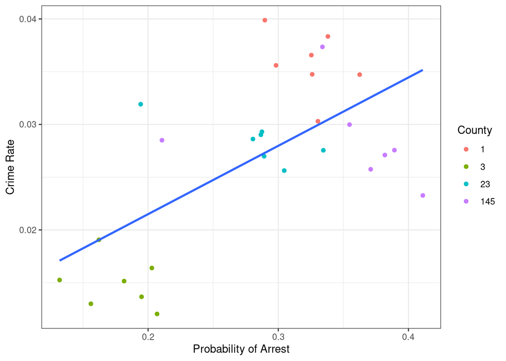

```r
css = crime4 %>%
  filter(county %in% c(1,3,145, 23))  # only keep these four counties

ggplot(css,aes(x =  prbarr, y = crmrte)) + # plot the regression line on four counties
  geom_point(mapping = aes(x = prbarr, y = crmrte, color = factor(county))) +
  geom_smooth(method="lm",se=FALSE) +
  theme_bw() +
  labs(x = 'Probability of Arrest', y = 'Crime Rate', color = "County")
```

By inspecting the figure we can see the `Pooled OLS` estimator suggests there is a strong positive relationship between the crime rate and the probability of arrest. That is, counties with higher arrest rates have higher crime rates.

Now, let’s actually look at two ways we can obtain the estimated effect using the `Pooled OLS` estimator. Both ways will produce the same estimated effects but the the second way will produce the correct standard errors on the estimates. The first approach simply uses the `lm()` function to estimate the regression, while the second approach involves loading the `estimatr` package and using the `lm_robust()` command to obtain the proper standard errors. What’s wrong with the standard errors in the first approach? Well, the first approach treats every observation as independent, which leads to much smaller standard errors on the estimated effects. This is because our data is correlated at the county level and therefore are not truly independent. Once we account for the clustered structure in the residuals, our standard errors become much larger and the estimated effect of the probability of arrest on crime rates are no longer significant at conventional levels.

```r
pols_bSE <- lm(crmrte ~ prbarr,data=css)
pols_gSE<- lm_robust(crmrte ~ prbarr,
                     se_type = "stata", # cluster-robust standard errors
                     clusters = county, # we are going to cluster at the county level
                     data = css)

export_summs(pols_bSE,pols_gSE, coefs = c('prbarr'), model.names = c("Bad S.E.", "Good S.E."), digits =2, stars = c(`***` = 0.01, `**` = 0.05, `*` = 0.1)) # print results to nice table
```

|  | Bad S.E. | Good S.E. |
| --- | --- | --- |
| prbarr | 0.06 *** | 0.06 |
|  | (0.02) | (0.04) |
| N | 28 | 28 |
| R2 | 0.39 | 0.39 |
| *** p < 0.01; ** p < 0.05; * p < 0.1. |  |  |

In general, the regressions suggests that a 10 percentage point increase in the probability of arrest leads to a `0.1*0.064801 = 0.0064801` percentage point increase in the crime rate. Does that make sense or are we missing something here? If the chance of getting arrested is high, wouldn’t that make individuals less likely to commit crimes? That’s certainly what I think should be the case.

Before we get into how to estimate the true effect using the `FE` estimator, let’s think more about what the `Pooled OLS` estimator is actually doing here with some graphs. We’ll start by plotting the average probability of arrest within each county. The differences in these averages across counties is the **Between Variation** I mentioned in the previous section. As already noted, we can see that *between* counties there is a strong positive relationship between the crime rate and the probability of arrest.

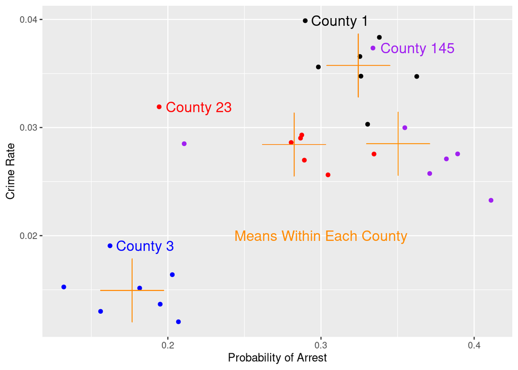

```r
css %>%
  filter(prbarr < .5) %>%
  group_by(county) %>%
  mutate(label = case_when(
    crmrte == max(crmrte) ~ paste('County',county),
    TRUE ~ NA_character_
  ),
  mcrm = mean(crmrte),
  mpr = mean(prbarr)) %>%
  ggplot(aes(x =  prbarr, y = crmrte, color = factor(county), label = label)) +
  geom_point() +
  geom_text(hjust = -.1, size = 14/.pt) +
  labs(x = 'Probability of Arrest',
       y = 'Crime Rate') +
  guides(color = "none", label = "none") +
  scale_color_manual(values = c('black','blue','red','purple')) +
  geom_point(aes(x = mpr, y = mcrm), size = 20, shape = 3, color = 'darkorange') +
  annotate(geom = 'text', x = .3, y = .02, label = 'Means Within Each County', color = 'darkorange', size = 14/.pt)
```

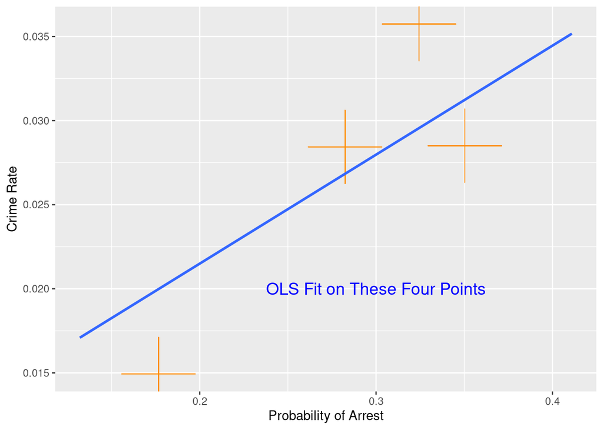

```r
css %>%
  filter(prbarr < .5) %>%
  group_by(county) %>%
  mutate(label = case_when(
    crmrte == max(crmrte) ~ paste('County',county),
    TRUE ~ NA_character_
  ),
  mcrm = mean(crmrte),
  mpr = mean(prbarr)) %>%
  ggplot(aes(x =  prbarr, y = crmrte, color = factor(county), label = label)) +
  labs(x = 'Probability of Arrest',
       y = 'Crime Rate') +
  guides(color = "none", label = "none")  +
  scale_color_manual(values = c('black','blue','red','purple')) +
  geom_point(aes(x = mpr, y = mcrm), size = 20, shape = 3, color = 'darkorange') +
  geom_smooth(aes(color = NULL), method = 'lm', se = FALSE)+
  annotate(geom = 'text', x = .3, y = .02, label = 'OLS Fit on These Four Points', color = 'blue', size = 14/.pt)
```

By treating the data set like a big cross-section we can see that the `POLS` estimator is simply recovering the *between* county variation. That is, it fits the regression line through the county level averages of the probability of arrest.

## 6.3 Fixed effects

In general, we are interested in estimating, $y_{it} = \alpha_i + \beta x_{it} + u_{it}$, where $\alpha_i$ is the fixed effect or unobserved effect that varies across individuals but not over time, $x_{it}$ is our independent regressor that varies over time and across individuals, and $u_{it}$ is the error term that varies across individuals and over time. If we do not control for the fixed effect our estimate of $\beta$ is going to be biased.

Now, going back to our example, let’s try to think about factors that might impact the crime rate in county *i*. You could imagine there are local factors like geography, the quality of schools, infrastructure, that is, things that do not change very much year-to-year within the county but there is likely variation across counties. So, not very much *within*-variation but a lot of *between*-variation. Similarly, culture, politics, and law and order may impact county level crime rates and also have little *within*-variation. Moreover, things like police budgets surely impact the crime rate and likely vary year-to-year and across counties. So, if we could find a way to remove all the *between*-variation we may have a shot at recovering the true effect of the probability of arrest on crime rates. Put differently, if all the endogeneity can be controlled for/only varies *between*-individuals, we can focus on the *within*-variation to identify the effects of interest. In essence, this is what the `Fixed Effect (FE)` estimator is doing. It removes all the *between*-unit level variation causing the omitted variable bias and leaves us with only *within*-unit level variation. In our case, by controlling for county fixed effects, the `FE` estimator will remove all the local factors, politics, culture, and law and order that vary across counties/also determine things like the police budget, and leaves us with only *within*-county variation.

In practice, how can we do this? There are two ways we could go about this. The first way would be to follow the `Dummy Variable` approach, where we would estimate the linear model controlling for county level dummies. The second approach is the `Within-transformation` method, where you regress the demeaned outcome variable against the demeaned independent variables. We’ll discuss this in more detail when we get there.

### 6.3.1 Dummy variable method

To implement the dummy variable method we can do the following:

```r
lsdv <- lm(crmrte ~ prbarr + factor(county), data = css)
export_summs(pols_gSE,lsdv, coefs = c('prbarr'),model.names=c("POLS","DV Method"), digits = 2, stars = c(`***` = 0.01, `**` = 0.05, `*` = 0.1))
```

|  | POLS | DV Method |
| --- | --- | --- |
| prbarr | 0.06 | -0.03 ** |
|  | (0.04) | (0.01) |
| N | 28 | 28 |
| R2 | 0.39 | 0.89 |
| *** p < 0.01; ** p < 0.05; * p < 0.1. |  |  |

As you can see, the effect of the probability of getting arrested on the crime rate is now negative instead of positive like it was in `POLS`. How do we interpret this effect? Given that this is within-county variation, the interpretation is the following, *comparing a county in year t with an arrest probability 100 percentage points higher than it is in year t+1, we can expect the crime rate to fall by around 3 percentage points in that same county*. Graphically speaking, this looks like the following:

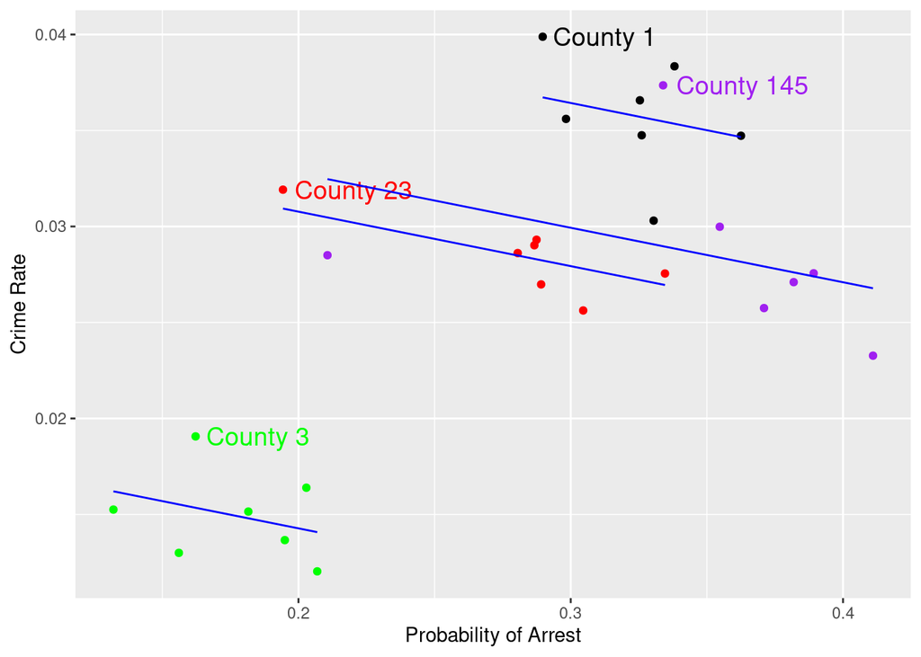

```r
css %>%
  ungroup() %>%
  mutate(pred = predict(lsdv)) %>%
  group_by(county) %>%
  mutate(label = case_when(
    crmrte == max(crmrte) ~ paste('County',county),
    TRUE ~ NA_character_
  )) %>%
  ggplot(aes(x =  prbarr, y = crmrte, color = factor(county), label = label)) +
  geom_point() +
  geom_text(hjust = -.1, size = 14/.pt) +
  geom_line(aes(y = pred, group = county), color = 'blue') +
  labs(x = 'Probability of Arrest',
       y = 'Crime Rate') +
  #scale_x_continuous(limits = c(.15, 2.5)) +
  guides(color = "none", label = "none") +
  scale_color_manual(values = c('black','green','red','purple'))
```

We can see there is a negative relationship within each county and each county has it’s own unique intercept.

### 6.3.2 Within transformation

While convenient, the `Dummy Variable (DV)` method can become computationally expesnive very quickly as the sample size grows. Instead of 4 counties, imagine we had 20,000, that would mean we would have to control for 19,999 dummy variables in the regression. Instead of the `DV` method, many leverage the `Within transformation` approach, which produces the exact same estimate of $\beta$ that the `DV` method obtains. To implement this method, we do the following steps:

- for all variables compute the time average for each unit *i*. In our example this means we compute $\bar{\alpha}_i = \alpha_i$, $\bar{x}_i = \frac{1}{T} \sum^T_{t=1} x_{it}$, and $\bar{y}_i = \frac{1}{T} \sum^T_{t=1} y_{it}$.
- for each observation, subtract the time averaged variables from the actual value, i.e., $\ddot{x}_{it} = (x_{it} - \bar{x}_i)$, $\ddot{y}_{it} = (y_{it} - \bar{y}_i)$, and $\ddot{\alpha}_{i} = 0$ (fixed effects do not vary over time, only across individuals)
- regress $\ddot{y}_{it}$ on $\ddot{x}_{it}$

Let’s try these steps out and compare our results the `DV` method:

```r
cdata <- css %>%
  group_by(county) %>%
  mutate(mean_crime = mean(crmrte), # mean y
         mean_prob = mean(prbarr)) %>% # mean x
  mutate(demeaned_crime = crmrte - mean_crime, # demeaned y
         demeaned_prob = prbarr - mean_prob) # demeaned x

within <- lm(demeaned_crime ~ demeaned_prob, data = cdata)
export_summs(pols_gSE,lsdv,within, coefs = c('prbarr','demeaned_prob'),model.names=c("POLS","DV Method","Within Method"), digits = 2, stars = c(`***` = 0.01, `**` = 0.05, `*` = 0.1))
```

|  | POLS | DV Method | Within Method |
| --- | --- | --- | --- |
| prbarr | 0.06 | -0.03 ** |  |
|  | (0.04) | (0.01) |  |
| demeaned_prob |  |  | -0.03 ** |
|  |  |  | (0.01) |
| N | 28 | 28 | 28 |
| R2 | 0.39 | 0.89 | 0.16 |
| *** p < 0.01; ** p < 0.05; * p < 0.1. |  |  |  |

As you can see, the effect of the probability of arrest on the crime rate is the exact same across the `DV` and `Within transformation` method. The interpretation of the coefficient is also the same. That said, when examining the $R^2$ in the `DV` and `Within transformation` regressions, you should be **very careful** when interpreting/comparing the $R^2$ as they are inherently measuring two different things. First, recall that the $R^2$ is a measure based on how much variation there is in our residuals relative to our dependent variable. The $R^2$ in the `DV` method tells us how much variation there is in the residuals relative to all the variation in the crime rate and counts the parts of the crime rate explained by between variation in our county level dummies. The $R^2$ in the `Within transformation` method tells us how much variation there is in the residuals relative to the *within* variation of the crime rate, not the *overall* variation in the crime rate, hence why this measure is often called the *within* $R^2$. In other words, demeaning takes the part explained by the fixed effects out, while the DV method does it *in* the regression.

Plotting the within transformed variables with a regression line demonstrates what the `within` Fixed Effect estimator is doing.

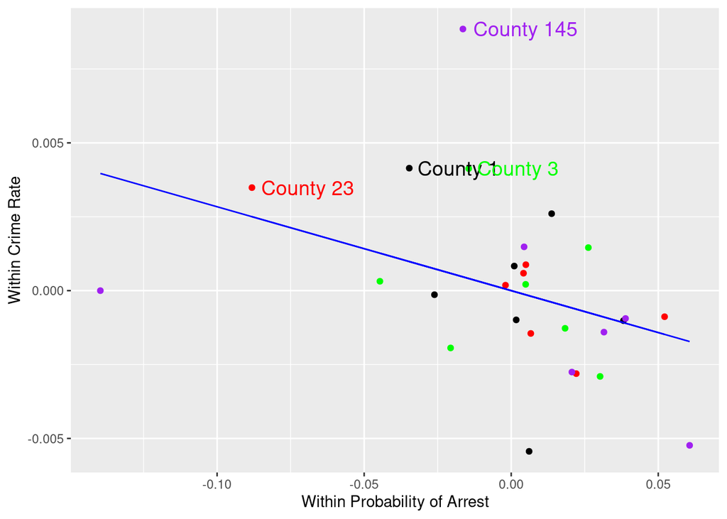

```r
cdata %>%
  ungroup() %>%
  mutate(pred = predict(within)) %>%
  group_by(county) %>%
  mutate(label = case_when(
    demeaned_crime == max(demeaned_crime) ~ paste('County',county),
    TRUE ~ NA_character_
  )) %>%
  ggplot(aes(x =  demeaned_prob, y = demeaned_crime, color = factor(county), label = label)) +
  geom_point() +
  geom_text(hjust = -.1, size = 14/.pt) +
  geom_line(aes(y = pred, group = county), color = 'blue') +
  labs(x = 'Within Probability of Arrest',
       y = 'Within Crime Rate') +
  #scale_x_continuous(limits = c(.15, 2.5)) +
  guides(color = "none", label = "none") +
  scale_color_manual(values = c('black','green','red','purple'))
```

### 6.3.3 Fixed Effects with user-defined packages

In practice, most researchers do not manually implement the fixed effect estimators we have been discussing, they usually turn to well regarded user-defined packages. The package I will use today is `fixest` as it tends to be the fastest. Let’s see how it works

```r
library(fixest)

upFE <- feols(crmrte ~ prbarr | county, css) # feols( y ~ x's | fixed effect variable, data)
export_summs(pols_gSE,lsdv,within, upFE, coefs = c('prbarr','demeaned_prob'),model.names=c("POLS","DV Method","Within Method","User-Package: fixest"), digits = 2, stars = c(`***` = 0.01, `**` = 0.05, `*` = 0.1))
```

|  | POLS | DV Method | Within Method | User-Package: fixest |
| --- | --- | --- | --- | --- |
| prbarr | 0.06 | -0.03 ** |  | -0.03 ** |
|  | (0.04) | (0.01) |  | (0.01) |
| demeaned_prob |  |  | -0.03 ** |  |
|  |  |  | (0.01) |  |
| N | 28 | 28 | 28 | 28 |
| R2 | 0.39 | 0.89 | 0.16 | 0.89 |
| *** p < 0.01; ** p < 0.05; * p < 0.1. |  |  |  |  |

As we expected, the estimates from the `feols()` package are the exact same as the estimates we obtained using the earlier methods.

### 6.3.4 Multiple sets of fixed effects

So far, we’ve seen how fixed effects methods allow us to identify variation that occurs *within* a variable. In our example, we had county fixed effects, so we were comparing the probability of arrest within a county to the same county over time. What if we had access to more than one set of fixed effects? If we had multiple sets, how could we use them? If we had access to more than one set of fixed effects we could use them by simply controlling for them in a regression. For instance, in the crime data set we’ve been using, we observe the same counties in multiple years so in practice we could include both county and year fixed effects in the regressions we’ve been working with so far.

In general, these specification are often called `Two-way fixed effect (TWFE)` models and often take the form,
$$\begin{aligned}
Y_{it} = \alpha_i + \beta_1 X_{it} + \delta_t + \epsilon_{it}.
\end{aligned}$$

When working with these models our interpretation will slightly change. Going back to our example, now, we are working with variation *within* a county and *within* a year. So, the variation that’s left can be thought of relative to what we would expect *given* the county, and *given* that year. As you can imagine, the interpretation can become a lot trickier with the addition of more fixed effects and can be tricky in general because the year effects can effect the individual effects and vice versa.

In practice, this model can be estimated using the same user-defined package as before:

```r
twFE <- feols(crmrte ~ prbarr | county + year, data = css)
export_summs(twFE, coefs = c('prbarr'),model.names=c("Two-way FE"), statistics = c(N = "nobs", R2 = "r.squared"), stars = c(`***` = 0.01, `**` = 0.05, `*` = 0.1), digits = 2)
```

|  | Two-way FE |
| --- | --- |
| prbarr | -0.01 |
|  | (0.01) |
| N | 28 |
| R2 | 0.95 |
| *** p < 0.01; ** p < 0.05; * p < 0.1. |  |

Keep in mind that `feols()` will cluster the standard errors on the first listed fixed effect variable in the regression by default. In our case, that’s county.

It’s also possible to include additional fixed effects that are not related to time. For example, you could have fixed effects for workers and for county, which are both unrelated to time. However, in this example it should be noted that you are isolating variation *within* a worker and *within* a county, which means in order for you to have any variation to be included, you would need to observe workers showing up in multiple counties. That is, the treatment effect would only depend on workers who switched counties over time. The treatment effect would not be based on workers who never switch counties over time. So, be careful.

## 6.4 Difference-in-Differences

Now that we have a basic understanding of two-way fixed effects, it should be fairly straightforward to understand `Difference-in-Differences (DID)` estimators. In `DID` there is a control (or comparison or untreated) group and a treated group. For `DID` to work, we need some kind of treatment that goes into effect at some point in time, and a group that receives said treatment and a group that does not. Ideally, the treated and untreated groups would be somewhat similar prior to the treatment coming into effect, but this isn’t a mandatory requirement for things to work. Then, by isolating and then comparing the *within* variation in both the treated and untreated groups we can determine *how much more the treated group changed compared to the untreated group when going from before to after*.

Okay, now how can we do this in practice? Well since we need to control for both group and time differences, we can simply use the `Two-Way Fixed Effects (TWFE)` estimator! That is, we can adapt the `TWFE` from the previous subsection,
$$\begin{aligned}
Y_{it} = \beta_0 + \beta_1 After_t + \beta_2 Treated_i + \beta_3 After_t \times Treated_i + \varepsilon_{it},
\end{aligned}$$

where $Treated_i$ is dummy that indicates whether an individual belongs to the treatment group and $After_t$ is a dummy that indicates the post-treatment period. How can we interpret the coefficients?

- $\beta_0$ – the untreated before mean, i.e., $Treated_i = 0 \ \text{and} \ After_t = 0$
- $\beta_1$ – the difference between the before and after for the untreated group
- $\beta_2$ – the difference between the treated and the untreated group before the treatment takes effect
- $\beta_3$ – how much bigger the before-after difference is for the treated group compared to the untreated group or how much bigger the treated/untreated gap grows after the treatment comes into effect. This is the coefficient of interest for `DID`!

This equation is commonly referred to as the `Two-Way Fixed Effect Difference-in-Differences (TWFE DID)` estimator since it has both group and time fixed effects. Moreover, this method is extremely popular because it can be easily estimated with simple OLS, just make sure you cluster the standard errors at the group level. If you do not, you will fail to account for the fact that the standard errors are likely correlated within groups over time and this will lead to over-precise standard errors.

Equivalently, you could also estimate this equation to obtain the exact same result:
$$\begin{aligned}
y = \alpha_g + \delta_t + \gamma_1 Treated + e,
\end{aligned}$$

where $\alpha_g$ is a group fixed effect, e.g., often just “treated” or “untreated”, $\delta_t$ is time fixed effect, e.g., often just “before treatment” and “after treatment”, and $Treated$ is an indicator equal to one if you are in the treated group during the post-treatment period. Here, $\gamma_1$ = $\beta_3$, i.e., it’s our `DID` effect.

#### 6.4.0.1 Earned Income Tax Credit Example

Let’s go through a quick example now. We’ll start by reading in a data set that contains information on US single women across various states in 1991–1996. The data also has information on how many children are in the household, the work status of the women, race, earnings, age, years of education, and other stuff. Let’s look at it below

```r
dfeitc <- read.csv('http://nickchk.com/eitc.csv')

head(dfeitc)
```

| state | year | urate | children | nonwhite | finc | earn | age | ed | work | unearn |
| --- | --- | --- | --- | --- | --- | --- | --- | --- | --- | --- |
| 11 | 1991 | 7.6 | 0 | 1 | 1.87e+04 | 1.87e+04 | 26 | 10 | 1 | 0 |
| 12 | 1991 | 7.2 | 1 | 0 | 4.84e+03 | 471 | 22 | 9 | 1 | 4.37 |
| 13 | 1991 | 6.4 | 2 | 0 | 8.18e+03 | 0 | 33 | 11 | 0 | 8.18 |
| 14 | 1991 | 9.1 | 0 | 1 | 9.37e+03 | 0 | 43 | 11 | 0 | 9.37 |
| 15 | 1991 | 8.6 | 3 | 1 | 1.47e+04 | 1.47e+04 | 23 | 7 | 1 | 0 |
| 16 | 1991 | 6.8 | 1 | 0 | 2.16e+04 | 1.89e+04 | 53 | 7 | 1 | 2.75 |

```r
summary(dfeitc)
```

```
##      state            year          urate           children
##  Min.   :11.00   Min.   :1991   Min.   : 2.600   Min.   :0.000
##  1st Qu.:31.00   1st Qu.:1992   1st Qu.: 5.700   1st Qu.:0.000
##  Median :56.00   Median :1993   Median : 6.800   Median :1.000
##  Mean   :54.52   Mean   :1993   Mean   : 6.762   Mean   :1.193
##  3rd Qu.:81.00   3rd Qu.:1995   3rd Qu.: 7.700   3rd Qu.:2.000
##  Max.   :95.00   Max.   :1996   Max.   :11.400   Max.   :9.000
##     nonwhite           finc             earn             age
##  Min.   :0.0000   Min.   :     0   Min.   :     0   Min.   :20.00
##  1st Qu.:0.0000   1st Qu.:  5123   1st Qu.:     0   1st Qu.:26.00
##  Median :1.0000   Median :  9637   Median :  3332   Median :34.00
##  Mean   :0.6007   Mean   : 15255   Mean   : 10432   Mean   :35.21
##  3rd Qu.:1.0000   3rd Qu.: 18659   3rd Qu.: 14321   3rd Qu.:44.00
##  Max.   :1.0000   Max.   :575617   Max.   :537881   Max.   :54.00
##        ed              work           unearn
##  Min.   : 0.000   Min.   :0.000   Min.   :  0.000
##  1st Qu.: 7.000   1st Qu.:0.000   1st Qu.:  0.000
##  Median :10.000   Median :1.000   Median :  2.973
##  Mean   : 8.806   Mean   :0.513   Mean   :  4.823
##  3rd Qu.:11.000   3rd Qu.:1.000   3rd Qu.:  6.864
##  Max.   :11.000   Max.   :1.000   Max.   :134.058
```

In 1993, President Clinton Signed Into Law the Largest EITC Expansion Ever. The President’s policy provided a tax cut for 15 million working families. For every dollar a very low-income working parent with one child earns, the EITC was increased from 23 cents to 34 cents (25 cents to 40 cents for two plus children). The Earned Income Tax Credit (EITC) a policy that promotes work for low- to moderate-income households by providing them with a refundable tax credit used to supplement their wages and help offset the effect of Social Security taxes. That is, you need to actually work to receive the benefits. You can read more about it here https://www.investopedia.com/terms/e/earnedincomecredit.asp and many other places, it’s a widely discussed policy. So, it’s easy to imagine this policy will increase the number of single mothers returning to work (treatment group), while the behavior of single women with no dependents will largely remain unchanged (control group).

The question is, does the EITC help single mothers get back to work? Let’s find out!

To get started will have to create our $After_t$ and $Treated_i$ variables. The post-treatment period will be all years after 1993 and our treatment group will contain all single mothers over this period of time in the data set.

```r
dfeitc <- dfeitc %>% mutate(after = year >= 1994, # create post-treatment period variable
                            treated = children > 0) # create treatment group variable
summary(dfeitc)
```

```
##      state            year          urate           children
##  Min.   :11.00   Min.   :1991   Min.   : 2.600   Min.   :0.000
##  1st Qu.:31.00   1st Qu.:1992   1st Qu.: 5.700   1st Qu.:0.000
##  Median :56.00   Median :1993   Median : 6.800   Median :1.000
##  Mean   :54.52   Mean   :1993   Mean   : 6.762   Mean   :1.193
##  3rd Qu.:81.00   3rd Qu.:1995   3rd Qu.: 7.700   3rd Qu.:2.000
##  Max.   :95.00   Max.   :1996   Max.   :11.400   Max.   :9.000
##     nonwhite           finc             earn             age
##  Min.   :0.0000   Min.   :     0   Min.   :     0   Min.   :20.00
##  1st Qu.:0.0000   1st Qu.:  5123   1st Qu.:     0   1st Qu.:26.00
##  Median :1.0000   Median :  9637   Median :  3332   Median :34.00
##  Mean   :0.6007   Mean   : 15255   Mean   : 10432   Mean   :35.21
##  3rd Qu.:1.0000   3rd Qu.: 18659   3rd Qu.: 14321   3rd Qu.:44.00
##  Max.   :1.0000   Max.   :575617   Max.   :537881   Max.   :54.00
##        ed              work           unearn          after
##  Min.   : 0.000   Min.   :0.000   Min.   :  0.000   Mode :logical
##  1st Qu.: 7.000   1st Qu.:0.000   1st Qu.:  0.000   FALSE:7401
##  Median :10.000   Median :1.000   Median :  2.973   TRUE :6345
##  Mean   : 8.806   Mean   :0.513   Mean   :  4.823
##  3rd Qu.:11.000   3rd Qu.:1.000   3rd Qu.:  6.864
##  Max.   :11.000   Max.   :1.000   Max.   :134.058
##   treated
##  Mode :logical
##  FALSE:5927
##  TRUE :7819
##
##
##
```

Our dependent variable will be “work”, which is a dummy equal to one if the person is working and zero otherwise. To estimate the effect of the EITC expansion we can simply run OLS!

```r
DID0 <- lm(work ~ after*treated, data = dfeitc)

export_summs(DID0,digits = 3 , stars = c(`***` = 0.01, `**` = 0.05, `*` = 0.1))
```

|  | Model 1 |
| --- | --- |
| (Intercept) | 0.575 *** |
|  | (0.009) |
| afterTRUE | -0.002 |
|  | (0.013) |
| treatedTRUE | -0.129 *** |
|  | (0.012) |
| afterTRUE:treatedTRUE | 0.047 *** |
|  | (0.017) |
| N | 13746 |
| R2 | 0.013 |
| *** p < 0.01; ** p < 0.05; * p < 0.1. |  |

But wait, we don’t have standard errors clustered at the group level. Let’s fix this by estimating the second equation in the previous subsection using `fixest` package.

```r
dfeitc <- dfeitc %>% mutate(Treated1 = children >0 & year >= 1994) # create alternative treatment variable. Could have also been Treated1 = treated*after.

DID1 <- feols(work ~ Treated1 | treated + after, dfeitc)
export_summs(DID0, DID1, digits = 3, model.names = c("DID w Bad S.E.'s", "DID w Good S.E.'s"), statistics = c(N = "nobs", R2 = "r.squared"), stars = c(`***` = 0.01, `**` = 0.05, `*` = 0.1) )
```

|  | DID w Bad S.E.'s | DID w Good S.E.'s |
| --- | --- | --- |
| (Intercept) | 0.575 *** |  |
|  | (0.009) |  |
| afterTRUE | -0.002 |  |
|  | (0.013) |  |
| treatedTRUE | -0.129 *** |  |
|  | (0.012) |  |
| afterTRUE:treatedTRUE | 0.047 *** |  |
|  | (0.017) |  |
| Treated1TRUE |  | 0.047 *** |
|  |  | (0.000) |
| N | 13746 | 13746 |
| R2 | 0.013 | 0.013 |
| *** p < 0.01; ** p < 0.05; * p < 0.1. |  |  |

According to our estimates, the EITC expansion increased the probability of working by 4.7 percentage points and the effect is significant.

**WARNING**: we don’t have time to discuss the parallel trends assumption, which is the main assumption required to argue that we are truly recovering the causal treatment effect of interest, but I would say this assumption is likely violated in more applications than it isn’t. To make matters worse, there is no way to test whether this assumption holds. So, make sure you understand your data, what you are trying to measure, and have arguments prepared for why this assumption holds in your context.

# 7 Event studies

Event studies are a lot like `Difference-in-Differences` except there is usually only one person or unit that’s tracked over multiple time periods, i.e., time series. The main idea behind event studies is that some kind of event occurs, which puts a treatment into effect that allows us to compare what happened before the event to after the event. This only really works if the treatment is the only that has changed. We can’t have the outcome of interest changing for some reason unrelated to the treatment, otherwise everything falls apart. In practice, we don’t know what would have happened if the treatment hadn’t occurred, so we are stuck with making predictions. This often means researchers have to extrapolate using data prior to the event occurring to predict what would of happened if the treatment never came in to effect. Then, they compare that prediction to what actually happened to estimate the size of the treatment effect.

This Section will borrow the event study examples found in Nick Huntington-Klein’s book titled, “**The Effect**”, which he has made freely available here https://theeffectbook.net/.

## 7.1 Event studies in practice

On August 10, 2015, Google announced that there would be major corporate structural changes made to the company. Specifically, a new parent company called “Alphabet” would own Google along with all that other stuff previously affiliated with Google like FitBit and Nest. To do an event study, we’ll follow four basic steps:

1. pick an estimation period far in advance of the event and also an observation period, which will cover just before and after the event. In our finance example, it will be several months before and after the announcement was made.
2. Using data from the estimation period, we’ll predict the outcome of interest, which was Google’ stock return. We can do this by taking the average of Google’s return in the estimation (**means-adjusted returns model**). Alternatively, we could also use what is known as the **markets-adjusted returns** model to predict the stock returns or the **risk-adjusted returns** model, which involves fitting a regression on the estimation period data where the outcome is Google’s daily stock return and the independent variable is the daily market return, then use that model in the observation period to predict Google’s stock return. I’ll do all three methods below.
3. In the observation period, we’ll subtract the prediction from the actual return, which will give us the “abnormal return (AR)”
4. Look at the AR in the observation period. If the AR is non-zero before the event, then the market may have anticipated the event. If the the AR is non-zero after the event, then that will tell us about the effect of the event on Google’s daily stock return.

With these steps in hand, let’s read in our data financial data.

```r
library(lubridate)
```

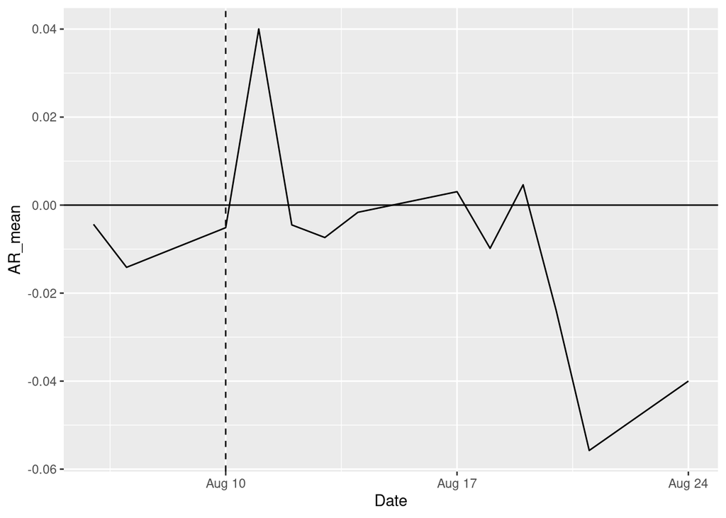

```r
library(ggplot2)

goog <- causaldata::google_stock

event <- ymd("2015-08-10") # date of our event (Google's corporate restructing announcement)

# Create estimation data set. We will use this to generate our predicted stock return for Google
est_data <- goog %>%
 filter(Date >= ymd('2015-05-01') &
 Date <= ymd('2015-07-31'))

# And observation data
obs_data <- goog %>%
 filter(Date >= event - days(4) &
 Date <= event + days(14))

# Estimate a model predicting stock price with market return. Here we will use the SP500 returns as a proxy for stock market return. This is needed for step 2.
m <- lm(Google_Return ~ SP500_Return, data = est_data)

# Compute abnormal return (AR): 3 different ways
obs_data <- obs_data %>%
 # 1. Using mean of estimation return
 mutate(AR_mean = Google_Return - mean(est_data$Google_Return),
 # 2. Then comparing to market return
 AR_market = Google_Return - SP500_Return,
 # 3. Then using model fit with estimation data
 risk_predict = predict(m, newdata = obs_data),
 AR_risk = Google_Return - risk_predict)

# Graphing all the results
ggplot(obs_data, aes(x = Date, y = AR_mean)) +
 geom_line() +
 geom_vline(aes(xintercept = event), linetype = 'dashed') +
 geom_hline(aes(yintercept = 0))
```

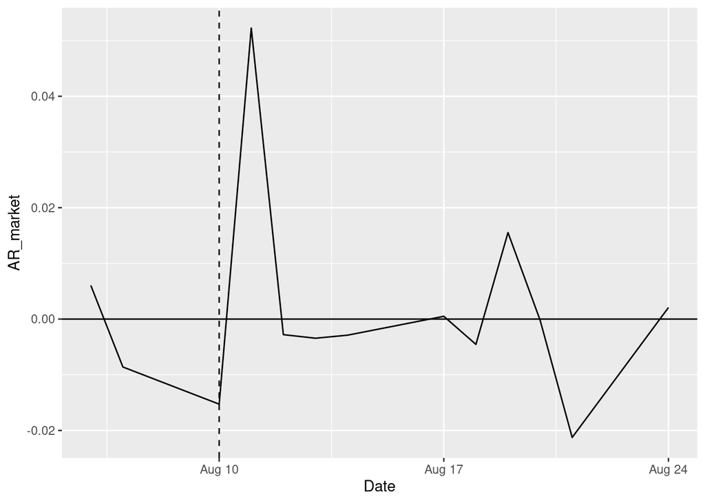

```r
ggplot(obs_data, aes(x = Date, y = AR_market)) +
 geom_line() +
 geom_vline(aes(xintercept = event), linetype = 'dashed') +
 geom_hline(aes(yintercept = 0))
```

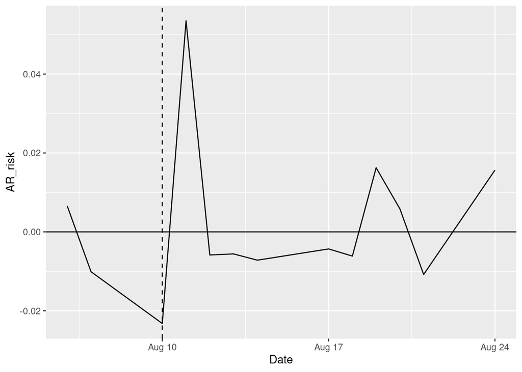

```r
ggplot(obs_data, aes(x = Date, y = AR_risk)) +
 geom_line() +
 geom_vline(aes(xintercept = event), linetype = 'dashed') +
 geom_hline(aes(yintercept = 0))
```

The figures suggests there is not a whole lot of action prior to Google’s announcement but there is a large spike in daily stock returns directly after the announcement is made, which is interesting! The former observation suggests this move was not anticipated by the market. Moreover, the effect of the announcement does not appear to last very long as Google’s daily market returns fall back down towards zero on August 12. Importantly, given how much can happen in a week in the stock market, I would not attribute the effects shown later on int he figure to be related to Google’s corporate restructuring announcement. So, keep the observation window small when doing these exercises.

For further examples on event studies and other things to consider when implementing them, you can check out the help page of the **estudy2** package in R.

# 8 Discrete variable models

In this section I will discuss non-linear binary response models (e.g., logit and probit), as well as ordinal response models (e.g., dependent variable is categorical with ordered categories), and then conclude by briefly going over models of censoring, truncation, and selection. I will briefly discuss how to estimate the models, interpret the coefficients, compute predictions, and compute marginal effects. Since this is such a big topic I will try to keep the examples as brief as possible in the interest time.

The examples covered in this section are based on several different sources that can be accessed via these links: https://sites.google.com/site/econometricsacademy/econometrics-models/probit-and-logit-models, https://scpoecon.github.io/ScPoEconometrics/binary.html, https://www.princeton.edu/~otorres/LogitR101.pdf, https://vincentarelbundock.github.io/marginaleffects/, https://sites.google.com/site/econometricsacademy/econometrics-models/multinomial-probit-and-logit-models, and https://sites.google.com/site/econometricsacademy/econometrics-models/ordered-probit-and-logit-models.

## 8.1 Binary response models

Binary outcome models estimate the probability that our outcome variable, $y$, equals one, conditional on a vector x of predictor variables. Specifically, we are interested in estimating
$$\begin{aligned}
E(Y | X) = Pr(Y=1|X) = F(\beta_0 + \beta_1 X), \ Y \in \{0,1\}
\end{aligned}$$

where $F(\cdot)$ is some function that maps any $z \in \mathbb{R}$ into a $(0,1)$ interval, which addresses the deficiencies that accompany the linear probability model. The most common functional forms you’ll see used in economics are the Probit and Logit models, which are displayed in the below plot

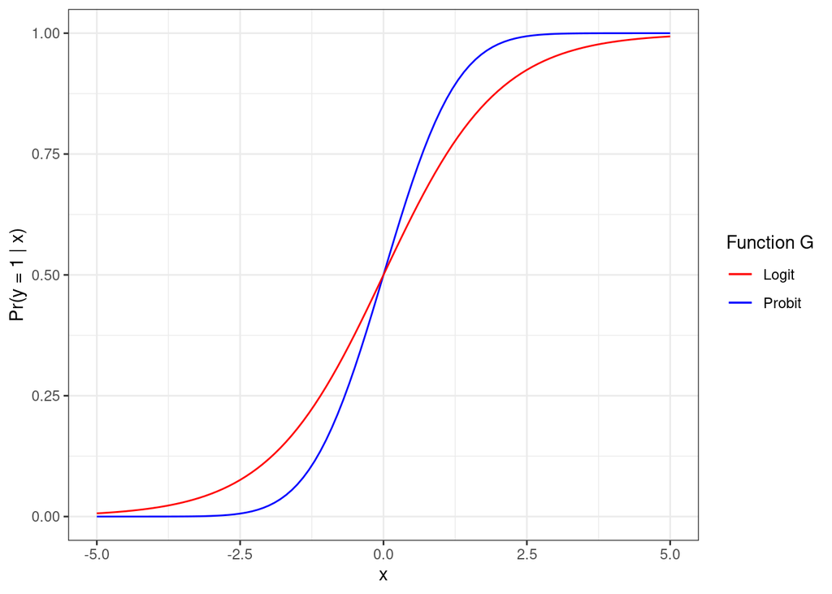

```r
library(ggplot2)
ggplot(data.frame(x = c(-5,5)), aes(x=x)) +
  stat_function(fun = pnorm, aes(colour = "Probit")) +
  stat_function(fun = plogis, aes(colour = "Logit")) +
  theme_bw() +
  scale_colour_manual(name = "Function G",values = c("red", "blue")) +
  scale_y_continuous(name = "Pr(y = 1 | x)")
```

As you can see, higher values of x are associated with a higher probability that the outcome variable equals one. You’ll also notice that *changes* in the probability will be much larger when say x goes from zero to one, than if x goes from 4 to 5. Last, no matter the value of x, the probability of success always falls in the $(0,1)$ interval.

Now let’s read in some data from David Card (1995), “Using Geographic Variation in College Proximity to Estimate the Return to Schooling” to see how these models work in practice. This data set contains 3010 individuals with 34 variables. The variables in the data set contain mostly information about demographic and labour market characteristics of workers. So, we have information about the individuals wages, years of job experience, school enrollment decisions, age, gender, race, etc. For our example, we will be trying to predict whether workers enrolled in college in 1976.

```r
library(wooldridge) # for data
library(marginaleffects) # for adjusted predictions and marginal effects later
library(jtools) # tools for summarizing output
library(huxtable) # tools for summarizing output
library(dplyr) # for data cleaning/manipulation
library(ggplot2) # for plots
library(fixest) # for probit and logit --- feglm()

data("card",package = "wooldridge")
help(card) # lists all variables and provides a bried description of the data set

summary(card)
```

```
##        id           nearc2           nearc4            educ
##  Min.   :   2   Min.   :0.0000   Min.   :0.0000   Min.   : 1.00
##  1st Qu.:1276   1st Qu.:0.0000   1st Qu.:0.0000   1st Qu.:12.00
##  Median :2541   Median :0.0000   Median :1.0000   Median :13.00
##  Mean   :2582   Mean   :0.4409   Mean   :0.6821   Mean   :13.26
##  3rd Qu.:3859   3rd Qu.:1.0000   3rd Qu.:1.0000   3rd Qu.:16.00
##  Max.   :5225   Max.   :1.0000   Max.   :1.0000   Max.   :18.00
##
##       age           fatheduc      motheduc         weight
##  Min.   :24.00   Min.   : 0    Min.   : 0.00   Min.   :  75607
##  1st Qu.:25.00   1st Qu.: 8    1st Qu.: 8.00   1st Qu.: 122798
##  Median :28.00   Median :10    Median :12.00   Median : 365200
##  Mean   :28.12   Mean   :10    Mean   :10.35   Mean   : 321185
##  3rd Qu.:31.00   3rd Qu.:12    3rd Qu.:12.00   3rd Qu.: 406024
##  Max.   :34.00   Max.   :18    Max.   :18.00   Max.   :1752340
##                  NA's   :690   NA's   :353
##     momdad14         sinmom14          step14            reg661
##  Min.   :0.0000   Min.   :0.0000   Min.   :0.00000   Min.   :0.00000
##  1st Qu.:1.0000   1st Qu.:0.0000   1st Qu.:0.00000   1st Qu.:0.00000
##  Median :1.0000   Median :0.0000   Median :0.00000   Median :0.00000
##  Mean   :0.7894   Mean   :0.1007   Mean   :0.03887   Mean   :0.04651
##  3rd Qu.:1.0000   3rd Qu.:0.0000   3rd Qu.:0.00000   3rd Qu.:0.00000
##  Max.   :1.0000   Max.   :1.0000   Max.   :1.00000   Max.   :1.00000
##
##      reg662           reg663           reg664            reg665
##  Min.   :0.0000   Min.   :0.0000   Min.   :0.00000   Min.   :0.0000
##  1st Qu.:0.0000   1st Qu.:0.0000   1st Qu.:0.00000   1st Qu.:0.0000
##  Median :0.0000   Median :0.0000   Median :0.00000   Median :0.0000
##  Mean   :0.1608   Mean   :0.1957   Mean   :0.06412   Mean   :0.2083
##  3rd Qu.:0.0000   3rd Qu.:0.0000   3rd Qu.:0.00000   3rd Qu.:0.0000
##  Max.   :1.0000   Max.   :1.0000   Max.   :1.00000   Max.   :1.0000
##
##      reg666            reg667         reg668            reg669
##  Min.   :0.00000   Min.   :0.00   Min.   :0.00000   Min.   :0.00000
##  1st Qu.:0.00000   1st Qu.:0.00   1st Qu.:0.00000   1st Qu.:0.00000
##  Median :0.00000   Median :0.00   Median :0.00000   Median :0.00000
##  Mean   :0.09601   Mean   :0.11   Mean   :0.02824   Mean   :0.09037
##  3rd Qu.:0.00000   3rd Qu.:0.00   3rd Qu.:0.00000   3rd Qu.:0.00000
##  Max.   :1.00000   Max.   :1.00   Max.   :1.00000   Max.   :1.00000
##
```

[output cut: 17 more lines]

```
##  Min.   : 50.0   Min.   :1.000   Min.   :0.0000   Min.   : 0.000
##  1st Qu.: 93.0   1st Qu.:1.000   1st Qu.:0.0000   1st Qu.: 6.000
##  Median :103.0   Median :1.000   Median :1.0000   Median : 8.000
##  Mean   :102.4   Mean   :2.271   Mean   :0.6743   Mean   : 8.856
##  3rd Qu.:113.0   3rd Qu.:4.000   3rd Qu.:1.0000   3rd Qu.:11.000
##  Max.   :149.0   Max.   :6.000   Max.   :1.0000   Max.   :23.000
##  NA's   :949     NA's   :7       NA's   :13
##      lwage          expersq
##  Min.   :4.605   Min.   :  0.00
##  1st Qu.:5.977   1st Qu.: 36.00
##  Median :6.287   Median : 64.00
##  Mean   :6.262   Mean   : 95.58
##  3rd Qu.:6.564   3rd Qu.:121.00
##  Max.   :7.785   Max.   :529.00
##
```

The variables we will include in our vector of controls for this exercise are:

- nearc2: =1 if near 2 yr college, 1966
- nearc4: =1 if near 4 yr college, 1966
- fatheduc: father’s schooling
- motheduc: mother’s schooling
- IQ: IQ score

To estimate Probit and Logit regressions we can leverage the **fixest** package again and use the `feglm()` command, which will also allow us to easily cluster our standard errors if needed, include instrumental variables, include fixed effects (this can be tricky, so be careful), and it’s also just really fast. Or, we can simply use the `glm()` function that comes with the installed with the base R packages. Either will work. I will use `glm()` since it’s a bit more functional with the **marginaleffects** package. Let’s see how this works below

```r
probit <- glm(enroll ~ factor(nearc2) + factor(nearc4) + fatheduc + motheduc + IQ,
              data = card,
              family = binomial(link = 'probit'))
logit  <- glm(enroll ~ factor(nearc2) + factor(nearc4) + fatheduc + motheduc  + IQ,
              data = card,
              family = binomial(link = 'logit'))

export_summs(probit,logit,
             model.names = c("Probit", "Logit"),
             digits = 3 , stars = c(`***` = 0.01, `**` = 0.05, `*` = 0.1),
             statistics = c(N = "nobs", BIC = "BIC") )
```

|  | Probit | Logit |
| --- | --- | --- |
| (Intercept) | -2.190 *** | -4.004 *** |
|  | (0.319) | (0.624) |
| factor(nearc2)1 | 0.035 | 0.079 |
|  | (0.086) | (0.165) |
| factor(nearc4)1 | 0.214 ** | 0.418 ** |
|  | (0.099) | (0.198) |
| fatheduc | 0.010 | 0.020 |
|  | (0.016) | (0.030) |
| motheduc | 0.007 | 0.016 |
|  | (0.019) | (0.036) |
| IQ | 0.006 * | 0.011 * |
|  | (0.003) | (0.006) |
| N | 1619 | 1619 |
| BIC | 1139.418 | 1139.122 |
| *** p < 0.01; ** p < 0.05; * p < 0.1. |  |  |

When interpreting the coefficients from these regressions you should keep in mind that a one-unit change in $X$ is the effect on the *index*, not our outcome $Y$ directly. Moreover, the coefficients can only tell us about the direction and significance of the regressor. For example, all else equal, individuals who lived near four year colleges in 1966 (nearc4=1) are more likely to be enrolled in school in 1976 relative to those who did not live near a four year college in 1966, and this effect is significant at the 5 percent level. All else equal, we can also see that individuals with higher IQ scores are more likely to enroll in college in 1976 and it’s significant at the ten percent level. Moreover, the signs and significance of the coefficients are the same in both the Logit and Probit models. This will generally be the case for the majority of applications, so it doesn’t really matter which model you choose to use for your projects. It really boils down to preference. I think a lot of people like the logit model because there is a closed form solution for the link function, which makes calculating marginal effects and predicted probabilities really easy. As a last note, if for some reason you were interested in comparing the magnitudes of the coefficients from the Probit and Logit models, you would simply multiply the Probit coefficients by 1.6.

Okay, now that we have a rough understanding of how to interpret the coefficients from these models, let’s think about how to calculate what we are really interested in, which is, *what is the effect of a one-unit increase (or an instantaneous change) in $X$ on $Y=1$*? To answer this question, we’ll need to compute the marginal effects. As I’ve alluded to in the earlier figure in this subsection, the marginal effect is going to heavily depend on how far $X$ is to the left or right in the figure. In essence, there is no *one* marginal effect, the effects will largely depend on how you treat the other regressors in the model, e.g., are you going to hold the other variables at their means or are you going to assign values to each of them? In general, there are four ways people compute marginal effects and this applies to all models covered in this entire section:

1. **The Marginal Effect of a Representative (MER)**: assign a value or set of values to the right-hand-side variables you’re interested in and calculate the marginal effect for them. For example, imagine we included an IQ-nearc4 interaction term in our regression, what is the marginal effect of living near a four year college on the probability of enrolling in college in 1976 at different levels of IQ, say 100, 150, and 200?
2. **The Average Marginal Effect (AME)**: calculate the marginal effect for each unit-level observation in your data set and take the average
3. **Marginal Effect at the Mean (MEM)**: calculate the marginal effect while holding each variable in the regression at their mean values
4. Summarize the entire distribution: similar to AME, calculate the marginal effect for each unit-level observation and then present the entire distribution

Before I show you how to compute the marginal effects, one other thing to consider when interpreting the effects is whether or not the variable of interest is continuous or discrete. If you are computing the marginal effect of a continuous variable on the outcome, the marginal effect applies to a very small change (or instantaneous change) in $X$, **not** a one-unit change in $X$. This is basically because our link function is non-linear, which means our marginal effects will be non-linear. If you are working with a discrete variable things become much easier to work with. For example, the effect of living near a four year college on the probability of enrolling in college would simply be the change from going from 0 (not living near 4 year college) to 1 (living near for year college). Hopefully, that makes sense. In any case, just be careful.

Now, let’s obtain some marginal effects using the **marginaleffects** package:

```r
# Average Marginal Effects (AME)
mfxprob_ame <- marginaleffects(probit) # computes a dataframe of marginal effects using probit coefficients
mfxlog_ame <- marginaleffects(logit)

head(mfxprob_ame) # as you can see, it computes the marginal effect for each of our true x's using the probit coefficients
```

| rowid | type | term | contrast | dydx | std.error | enroll | nearc2 | nearc4 | fatheduc | motheduc | IQ |
| --- | --- | --- | --- | --- | --- | --- | --- | --- | --- | --- | --- |
| 1 | response | nearc2 | 1 - 0 | 0.00452 | 0.0111 | 0 | 0 | 0 | 8 | 8 | 93 |
| 2 | response | nearc2 | 1 - 0 | 0.00558 | 0.0136 | 0 | 0 | 0 | 14 | 12 | 103 |
| 3 | response | nearc2 | 1 - 0 | 0.00635 | 0.0154 | 0 | 1 | 1 | 11 | 12 | 88 |
| 4 | response | nearc2 | 1 - 0 | 0.00672 | 0.0163 | 0 | 1 | 1 | 8 | 7 | 108 |
| 5 | response | nearc2 | 1 - 0 | 0.00605 | 0.0147 | 0 | 1 | 1 | 9 | 12 | 85 |
| 6 | response | nearc2 | 1 - 0 | 0.00818 | 0.0198 | 0 | 1 | 1 | 14 | 14 | 119 |

```r
# Marginal Effects at Means (MEM)
mfxprob_mem <- marginaleffects(probit,newdata = datagrid()) # "newdata = datagrid()" tells marginaleffects to hold all variables at their mean
mfxlog_mem <- marginaleffects(logit,newdata = datagrid())

head(mfxprob_mem) # as you can see, it computes the marginal effect for each of the average x's using the probit coefficients
```

| rowid | type | term | contrast | dydx | std.error | nearc2 | nearc4 | fatheduc | motheduc | IQ |
| --- | --- | --- | --- | --- | --- | --- | --- | --- | --- | --- |
| 1 | response | nearc2 | 1 - 0 | 0.00699 | 0.0169 | 0 | 1 | 10.6 | 11 | 104 |
| 1 | response | nearc4 | 1 - 0 | 0.0361 | 0.0162 | 0 | 1 | 10.6 | 11 | 104 |
| 1 | response | fatheduc |  | 0.002 | 0.00303 | 0 | 1 | 10.6 | 11 | 104 |
| 1 | response | motheduc |  | 0.00136 | 0.00359 | 0 | 1 | 10.6 | 11 | 104 |
| 1 | response | IQ |  | 0.00108 | 0.000591 | 0 | 1 | 10.6 | 11 | 104 |

```r
# Marginal Effects at Representative values (MER)
mfxlog_mer <- marginaleffects(logit ,
                newdata = datagrid(IQ = 500, model = logit)) # let's make every single person a genius in the model and leave everything else unchanged
mfxprob_mer <- marginaleffects(probit,
                newdata = datagrid(IQ = 500, model = probit)) # let's make every single person a genius in the model and leave everything else unchanged

head(mfxlog_mer) # check that IQ=500 for everyone
```

| rowid | type | term | contrast | dydx | std.error | nearc2 | nearc4 | fatheduc | motheduc | IQ |
| --- | --- | --- | --- | --- | --- | --- | --- | --- | --- | --- |
| 1 | response | nearc2 | 1 - 0 | 0.00651 | 0.0181 | 0 | 1 | 10.6 | 11 | 500 |
| 1 | response | nearc4 | 1 - 0 | 0.0422 | 0.0779 | 0 | 1 | 10.6 | 11 | 500 |
| 1 | response | fatheduc |  | 0.00173 | 0.00448 | 0 | 1 | 10.6 | 11 | 500 |
| 1 | response | motheduc |  | 0.00135 | 0.0042 | 0 | 1 | 10.6 | 11 | 500 |
| 1 | response | IQ |  | 0.000931 | 0.00123 | 0 | 1 | 10.6 | 11 | 500 |

```r
 # AME's displayed under estimate column
summary(mfxprob_ame)
```

| type | term | contrast | estimate | std.error | statistic | p.value | conf.low | conf.high |
| --- | --- | --- | --- | --- | --- | --- | --- | --- |
| response | fatheduc |  | 0.00191 | 0.00288 | 0.662 | 0.508 | -0.00374 | 0.00755 |
| response | IQ |  | 0.00103 | 0.000564 | 1.82 | 0.0681 | -7.66e-05 | 0.00213 |
| response | motheduc |  | 0.00129 | 0.00342 | 0.379 | 0.705 | -0.0054 | 0.00799 |
| response | nearc2 | 1 - 0 | 0.00652 | 0.0158 | 0.412 | 0.68 | -0.0245 | 0.0375 |
| response | nearc4 | 1 - 0 | 0.037 | 0.0162 | 2.28 | 0.0223 | 0.00526 | 0.0687 |

```r
 # AME's displayed under estimate column
summary(mfxlog_ame)
```

| type | term | contrast | estimate | std.error | statistic | p.value | conf.low | conf.high |
| --- | --- | --- | --- | --- | --- | --- | --- | --- |
| response | fatheduc |  | 0.00194 | 0.00289 | 0.672 | 0.501 | -0.00372 | 0.00761 |
| response | IQ |  | 0.00104 | 0.000567 | 1.84 | 0.0657 | -6.77e-05 | 0.00215 |
| response | motheduc |  | 0.00151 | 0.00345 | 0.439 | 0.66 | -0.00524 | 0.00827 |
| response | nearc2 | 1 - 0 | 0.00754 | 0.0158 | 0.477 | 0.633 | -0.0234 | 0.0385 |
| response | nearc4 | 1 - 0 | 0.037 | 0.0162 | 2.28 | 0.0226 | 0.0052 | 0.0689 |

```r
# Marginal Effects all in a single table
export_summs(mfxlog_ame, mfxlog_mem,mfxlog_mer,mfxprob_ame,mfxprob_mem, mfxprob_mer,
             model.names = c("AME's Logit", "MEM's Logit","MER's Logit", "AME's Probit","MEM's Probit", "MER's Probit"),
             digits=3,
             statistics = NULL,
             stars = c(`***` = 0.01, `**` = 0.05, `*` = 0.1))
```

|  | AME's Logit | MEM's Logit | MER's Logit | AME's Probit | MEM's Probit | MER's Probit |
| --- | --- | --- | --- | --- | --- | --- |
| fatheduc | 0.002 | 0.002 | 0.002 | 0.002 | 0.002 | 0.002 |
|  | (0.003) | (0.003) | (0.004) | (0.003) | (0.003) | (0.005) |
| IQ | 0.001 * | 0.001 * | 0.001 | 0.001 * | 0.001 * | 0.001 |
|  | (0.001) | (0.001) | (0.001) | (0.001) | (0.001) | (0.001) |
| motheduc | 0.002 | 0.002 | 0.001 | 0.001 | 0.001 | 0.002 |
|  | (0.003) | (0.004) | (0.004) | (0.003) | (0.004) | (0.005) |
| nearc2 | 0.008 | 0.008 | 0.007 | 0.007 | 0.007 | 0.008 |
|  | (0.016) | (0.017) | (0.018) | (0.016) | (0.017) | (0.022) |
| nearc4 | 0.037 ** | 0.036 ** | 0.042 | 0.037 ** | 0.036 ** | 0.056 |
|  | (0.016) | (0.016) | (0.078) | (0.016) | (0.016) | (0.068) |
| nobs | 0 | 0 | 0 | 0 | 0 | 0 |
| *** p < 0.01; ** p < 0.05; * p < 0.1. |  |  |  |  |  |  |

What if we had interactions in our model and want to plot out the effects conditional on some other variable? Let’s add interactions to our logit model to test out what happens!

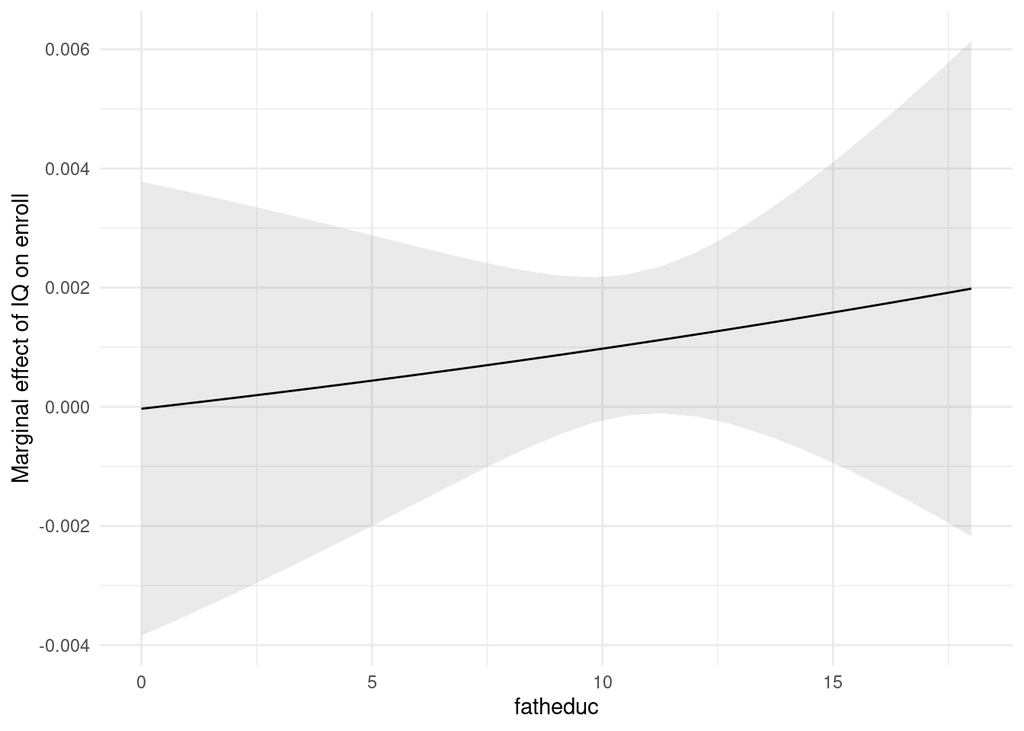

```r
logit_int  <- glm(enroll ~ factor(nearc2) + factor(nearc4) + IQ*(fatheduc + motheduc)  ,
              data = card,
              family = binomial(link = 'logit'))

plot_cme(logit_int, effect = "IQ", condition = "fatheduc")
```

This figure shows us how the marginal effect of IQ on the probability of college enrollment changes with years of fathers education. Specifically, we can see the marginal effect of IQ on the probability of college enrollment increases with fathers education but the effect is never statistically significant at conventional levels. It is a conditional marginal effects plot.

## 8.2 Ordinal response models

If your dependent variable has more than two categories and the categories have a distinct ordering, then you’ll want to use an Ordered Probit or Logit model. For example, imagine our dependent variable had four categories that described how worker’s skills have changed over a two year period. The possible responses are, “decrease = 0”, “no change = 1”, “small increase = 2”, and “large increase = 3”. Clearly, there is an obvious ranking in this variable where “large increase = 3” is the largest (or ranked first) and “decrease = 0” is the smallest (or would be ranked last). Other examples of ordered categorical variables include things related to rating systems (poor, fair, good, excellent), opinion surveys (strongly agree, agree, neutral, disagree, strongly disagree), grades (A,B,C,D), and employment (unemployed, part time, full time).

Going back to our skill variable example, even though there is a distinct ranking in the variable, the difference between going from skill decrease to no change may not be the same as going from small increase to large increase. So, we use the Ordered Probit or Logit models to estimate different cutoffs that would basically tell us when a respondent would report each category. That is, the Ordered Probit and Logit models are index models for a single latent variable that we’ll call $y^*_i$,
$$\begin{aligned}
y^*_i = X' \beta + u_i, \\
y_i = j \ \text{if} \ \kappa_{j-1} < y^*_i \leq \kappa_j,
\end{aligned}$$
where $\kappa_j$ are the estimated thresholds and $y_i$ is the observed categorical response. Then, the probability that person $i$ will select alternative $j$ is
$$\begin{aligned}
Pr(y_i = j | X) = Pr(\kappa_{j-1} < y^*_i \leq \kappa_j | X) = F(\kappa_j - X'\beta) - F(\kappa_{j-1} - X'\beta),
\end{aligned}$$

where $F(\cdot)$ is the Logistic CDF in the Ordered Logit model and the standard Normal CDF for the Ordered Probit model.

When estimating these models for a dependent variable with $j$ alternative, there will be estimates for all coefficients and $j-1$ intercepts reported. The only thing that the sign of the coefficients in the regression output tells you is whether the latent variable $y^*_i$ is increasing with the regressor.

Okay, now let’s get into our example. This example is from Econometrics Academy, which can be accessed via this link https://sites.google.com/site/econometricsacademy/econometrics-models/ordered-probit-and-logit-models.

```r
library(MASS) # for ordered probit and logit --- polr()# marginal effects and predictions
library(jtools) # nice tables

healthdata <- read.csv("/home/tommas/DDrive/Dropbox/ECON_4400_GTA_202122/R_files/ordered_health.csv",header=TRUE)

healthdata <- healthdata %>% mutate(hs1 = as.factor(healthstatus1),
                                    agegroup = ifelse(age <= 25,0,
                                                      ifelse(age > 25 & age <= 40,1,
                                                             ifelse(age >40,2,NA))) # categorize the age variable for example below
                                    )


head(healthdata)
```

| healthstatus | age | logincome | numberdiseases | healthstatus1 | hs1 | agegroup |
| --- | --- | --- | --- | --- | --- | --- |
| good | 43.9 | 9.53 | 13.7 | 2 | 2 | 2 |
| excellent | 17.6 | 9.53 | 13.7 | 3 | 3 | 0 |
| excellent | 15.5 | 9.53 | 13.7 | 3 | 3 | 0 |
| good | 44.1 | 9.53 | 13.7 | 2 | 2 | 2 |
| good | 14.5 | 8.54 | 13.7 | 2 | 2 | 0 |
| good | 16.3 | 8.54 | 13 | 2 | 2 | 0 |

```r
summary(healthdata)
```

```
##  healthstatus            age             logincome      numberdiseases
##  Length:5574        Min.   : 0.02533   Min.   : 0.000   Min.   : 0.00
##  Class :character   1st Qu.:11.34086   1st Qu.: 8.570   1st Qu.: 6.90
##  Mode  :character   Median :24.13210   Median : 8.976   Median :10.58
##                     Mean   :25.57613   Mean   : 8.697   Mean   :11.21
##                     3rd Qu.:37.19781   3rd Qu.: 9.251   3rd Qu.:13.73
##                     Max.   :63.27515   Max.   :10.283   Max.   :58.60
##  healthstatus1   hs1         agegroup
##  Min.   :1.000   1: 523   Min.   :0.0000
##  1st Qu.:2.000   2:2034   1st Qu.:0.0000
##  Median :3.000   3:3017   Median :0.0000
##  Mean   :2.447            Mean   :0.6961
##  3rd Qu.:3.000            3rd Qu.:1.0000
##  Max.   :3.000            Max.   :2.0000
```

Our dependent variable in this exercise will be health status (hs1) and our regressors will be age, log income, and number of diseases. Let’s get started

```r
ologit <- polr(hs1 ~ age + numberdiseases + logincome, data=healthdata, Hess=TRUE)
oprobit <- polr(hs1 ~ age + numberdiseases + logincome, data=healthdata, Hess=TRUE, method = "probit")

export_summs(ologit,oprobit,
             model.names = c("Ordered Logit","Ordered Probit"),
             digits=3,
             stars = c(`***` = 0.01, `**` = 0.05, `*` = 0.1),
             statistics = c(N = "nobs", BIC = "BIC") )
```

|  | Ordered Logit | Ordered Probit |
| --- | --- | --- |
| age | -0.029 | -0.017 |
|  | (0.002) | (0.001) |
| numberdiseases | -0.055 | -0.032 |
|  | (0.004) | (0.002) |
| logincome | 0.284 | 0.165 |
|  | (0.023) | (0.013) |
| 1\|2 | -1.396 | -0.795 |
|  | (0.206) | (0.115) |
| 2\|3 | 0.951 | 0.546 |
|  | (0.205) | (0.115) |
| N | 5574.000 | 5574.000 |
| BIC | 9582.834 | 9585.189 |
| *** p < 0.01; ** p < 0.05; * p < 0.1. |  |  |

Now for some strange reason the stars are not showing up on the coefficients in the regression table, but by looking at the standards errors and computing the 95% C.I. for each coefficient you can easily see that they are all statistically significant. In both the Ordered Logit and Probit models, we can see that older individuals are less likely to report they’re in excellent health, individuals with higher numbers of diseases are less likely to report they’re in excellent health, and workers with higher levels of income are more likely to report they’re in excellent health. We can also see the cutoffs are significant, which suggests we should not combine categories in the dependent variable.

Unfortunately, this is the only package I could find that worked with these models. It doesn’t work well with categorical variables but does obtain the correct results for continuous and binary variables. Each row should approximately sum to zero, I say approximately because there is some minor rounding error. If someone is aware of a package that is more flexible than the one I’m using please let me know.

```r
library(erer) # for marginal effects in ordinal response models
# AME's
mfxolog <- ocME(ologit)
mfxoprob <- ocME(oprobit)

print(mfxolog)
```

```
##                effect.1 effect.2 effect.3
## age               0.002    0.005   -0.007
## numberdiseases    0.004    0.010   -0.014
## logincome        -0.020   -0.051    0.071
```

```r
print(mfxoprob)
```

```
##                effect.1 effect.2 effect.3
## age               0.002    0.004   -0.007
## numberdiseases    0.004    0.008   -0.013
## logincome        -0.023   -0.042    0.066
```

## 8.3 Limited dependent variable models

This subsection will cover Tobit, Truncated regression, and Heckman Selection models. The code and examples were lifted from https://sites.google.com/site/econometricsacademy/econometrics-models/limited-dependent-variable-models.

We use limited dependent variable models when our dependent variables have some kind of limit or boundary and many observations are hitting this limit or boundary. A common example used in labour economics is Labour the labor supply (hours worked) by women with some women choosing not to work (zero hours) and others choosing to work a positive number of hours. What is censoring and truncation?

- **Censored Sample** — when we observe observations in the sample at this limit or boundary (our sample contains women with zero hours of work and positive hours of work)
- **Truncated Sample** — we are missing observations in the sample, e.g., we only observe workers with positive hours worked and therefore do not observe anything about workers who choose not work $\implies$ much greater loss of information

Both situations lead to bias.

In the example we are covering today, we want to study the factors influencing ambulatory expenditures. The data are from the 2001 Medical Expenditure Panel Survey (2001). Overall, there are 3328 observations in the data set. Our dependent variable is going to be ambulatory expenditures and has 526 zero observations. The variables included in our vector of controls will be age, female, and total number of chronic conditions. Let’s start by summarizing our data.

```r
# install.packages("VGAM")
library(VGAM)
# install.packages("AER")
library(AER)
# install.packages("truncreg")
library(truncreg)
# install.packages("censReg")
library(censReg)

mydata<- read.csv("/home/tommas/DDrive/Downloads/limdep_ambexp.csv")
attach(mydata)

# Define variables
Y <- cbind(ambexp)
X <- cbind(age, female, totchr)

# Descriptive statistics
summary(Y)
```

```
##      ambexp
##  Min.   :    0.0
##  1st Qu.:  113.0
##  Median :  534.5
##  Mean   : 1386.5
##  3rd Qu.: 1618.0
##  Max.   :49960.0
```

```r
summary(X)
```

```
##       age            female           totchr
##  Min.   :2.100   Min.   :0.0000   Min.   :0.0000
##  1st Qu.:3.100   1st Qu.:0.0000   1st Qu.:0.0000
##  Median :4.000   Median :1.0000   Median :0.0000
##  Mean   :4.057   Mean   :0.5084   Mean   :0.4832
##  3rd Qu.:4.900   3rd Qu.:1.0000   3rd Qu.:1.0000
##  Max.   :6.400   Max.   :1.0000   Max.   :5.0000
```

Now let’s look at how to estimate our Tobit regressions in using two different packages. Both should be equivalent. We’ll start by using `tobit()` and then estimate the same equation using `censReg()`. In general, you need to specify values for the upper and lower boundary, i.e., the values are associated with censoring, in our example it is zero. Unfortunately, our `export_summs()` does not work with these packages so we’ll be stuck summarizing the results with `stargazer()`. Remember, if we just tried to estimate this regression using OLS we would not be accounting for the systematic or non-random selection into the censored group and would obtain biased result.

```r
library(stargazer)
# Tobit model coefficients (censoring from below at 0 or left censored)
tobit1 <- tobit(Y ~ X, left=0, right=Inf, data=mydata) # tobit(formula, left = boundary below (-Inf if no boundary), right = boundary above (=Inf if no boundary), data)
tobit2 <- censReg(Y ~ X, left=0, right=Inf, data=mydata)
stargazer(tobit1,tobit2,type= 'text')
```

```
##
## =====================================================
##                            Dependent variable:
##                     ---------------------------------
##                                     Y
##                            Tobit          censored
##                                          regression
##                             (1)              (2)
## -----------------------------------------------------
## Xage                    332.843***       332.843***
##                          (42.288)         (42.288)
##
## Xfemale                 691.126***       691.126***
##                          (93.055)         (93.055)
##
## Xtotchr                1,260.687***     1,260.687***
##                          (60.674)         (60.674)
##
## logSigma                                  7.860***
##                                            (0.014)
##
## Constant               -1,237.282***    -1,237.282***
##                          (181.811)        (181.811)
##
## -----------------------------------------------------
## Observations               3,328            3,328
## Log Likelihood          -26,386.120      -26,386.120
## Akaike Inf. Crit.                        52,782.240
## Bayesian Inf. Crit.                      52,812.790
## Wald Test           685.604*** (df = 3)
## =====================================================
## Note:                     *p<0.1; **p<0.05; ***p<0.01
```

```r
# Tobit model marginal effects for the censored sample
summary(margEff(tobit2))
```

```
##         Marg. Eff. Std. Error t value  Pr(>|t|)
## Xage       219.919     27.978  7.8603 5.107e-15 ***
## Xfemale    456.646     61.458  7.4303 1.372e-13 ***
## Xtotchr    832.971     40.745 20.4434 < 2.2e-16 ***
## ---
## Signif. codes:  0 '***' 0.001 '**' 0.01 '*' 0.05 '.' 0.1 ' ' 1
```

From the Tobit output we can say that individuals who are older, female, or have more chronic conditions have higher latent ambulatory expenditures. A one-unit increase in an individual’s age would suggest they have an additional $333 in “desired” or latent ambulatory expenditures. The marginal effects from the censored sample tell us that if an individual becomes one year older we can expect they have an additional $220 in actual ambulatory expenditures.

```r
# Heckman model: two ways to get the exact same results
# install.packages("sampleSelection")
library(sampleSelection)
heckman1 <- heckit(selection = (Y>0) ~ X, outcome = Y ~ X, method = "ml")
#summary(heckman1) it's the exact same so uncomment to check for yourself

heckman2 <- selection((Y>0) ~ X, Y ~ X, data = mydata)
summary(heckman2)
```

```
## --------------------------------------------
## Tobit 2 model (sample selection model)
## Maximum Likelihood estimation
## Newton-Raphson maximisation, 2 iterations
## Return code 3: Last step could not find a value above the current.
## Boundary of parameter space?
## Consider switching to a more robust optimisation method temporarily.
## Log-Likelihood: -26800.38
## 3328 observations (526 censored and 2802 observed)
## 10 free parameters (df = 3318)
## Probit selection equation:
##              Estimate Std. Error t value Pr(>|t|)
## (Intercept) -0.005033   0.101597  -0.050     0.96
## Xage         0.114003   0.025441   4.481 7.68e-06 ***
## Xfemale      0.612199   0.062525   9.791  < 2e-16 ***
## Xtotchr      0.772925   0.084918   9.102  < 2e-16 ***
## Outcome equation:
##             Estimate Std. Error t value Pr(>|t|)
## (Intercept) -1400.24     196.43  -7.128 1.24e-12 ***
## Xage          350.06      45.31   7.726 1.46e-14 ***
## Xfemale       692.43      99.57   6.954 4.25e-12 ***
## Xtotchr      1295.33      64.46  20.094  < 2e-16 ***
##    Error terms:
##        Estimate Std. Error t value Pr(>|t|)
## sigma 2729.4012    41.0617   66.47   <2e-16 ***
## rho      0.9121         NA      NA       NA
## ---
## Signif. codes:  0 '***' 0.001 '**' 0.01 '*' 0.05 '.' 0.1 ' ' 1
## --------------------------------------------
```

From the Probit coefficients in the Heckman output we can say that individuals who are older, female, or have more chronic conditions are more likely to have positive ambulatory expenditures. We can see in the outcome equation for the truncated sample that a one unit increase in age is associated with $350 more in ambulatory expenditures. Moreover, the results are similar to what we found in the Tobit regressions.

# 9 Dynamic panel data models

This is example was taken from Professor Saunders **R for Economics** course found here https://www.youtube.com/watch?v=-oaVYdViz-g&list=PLCzsA9hMKGoaSukVTfFzzTn38IcYSjSGq&index=4.

Since our $X$ variables contain the lags of our dependent variable, this is going to lead to an endogeneity problem, which means we’ll need to use Fixed Effects or instrumental variables to correct this problem. Thus, our instrument set will be $Z$. That data we’ll be using comes from the UK and it contains data on firms, wages, capital, etc. Employment will be a function of lagged employment, wages, capital, and output. The further lags of employment will be the actual instruments. We’ll estimate the equation in several different ways: the first difference estimator, the index specified where we’ll specify the exact fixed effects to used in estimation, the system estimator approach (see Charles’s video for brief explanation), and an approach that reduces the number of instruments used.

```r
# Dynamic Panel GMM
#    - data indexed by individual (i) and time (t)

#  General GMM formula:  "Y(i,t) ~ X(i,t) | Z(i,t)"
#    Y - Dependent variable
#    X - Endogenous variable; includes the lags of Y(i,t-1) for dynamics. this leads to an endoegneity issue with the errors
#    Z - Instrument set


#install.packages("plm")
library(plm)

# package sample data
data("EmplUK", package = "plm")
summary(EmplUK)
```

```
##       firm            year          sector           emp
##  Min.   :  1.0   Min.   :1976   Min.   :1.000   Min.   :  0.104
##  1st Qu.: 37.0   1st Qu.:1978   1st Qu.:3.000   1st Qu.:  1.181
##  Median : 74.0   Median :1980   Median :5.000   Median :  2.287
##  Mean   : 73.2   Mean   :1980   Mean   :5.123   Mean   :  7.892
##  3rd Qu.:110.0   3rd Qu.:1981   3rd Qu.:8.000   3rd Qu.:  7.020
##  Max.   :140.0   Max.   :1984   Max.   :9.000   Max.   :108.562
##       wage           capital            output
##  Min.   : 8.017   Min.   : 0.0119   Min.   : 86.9
##  1st Qu.:20.636   1st Qu.: 0.2210   1st Qu.: 97.1
##  Median :24.006   Median : 0.5180   Median :100.6
##  Mean   :23.919   Mean   : 2.5074   Mean   :103.8
##  3rd Qu.:27.494   3rd Qu.: 1.5010   3rd Qu.:110.6
##  Max.   :45.232   Max.   :47.1079   Max.   :128.4
```

```r
# breaking down the model:
#   log(emp) ~ lag(log(emp), 1:2) + lag(log(wage), 0:1) + log(capital) + lag(log(output), 0:1) | lag(log(emp), 2:99)"
#
#    Y(i,t) = log(emp)              ==> employment(i,t)
#    X(i,t) = lag(log(emp), 1:2)    ==> Y(i,t-1) and Y(i,t-2)
#             lag(log(wage), 0:1)   ==> wage(i,t) and wage(i,t-1)
#             log(capital)          ==> capital(i,t)
#             lag(log(output), 0:1) ==> output(i,t) and output(i,t-1)
#    Z(i,t) = lag(log(emp), 2:99)   ==> Y(i,t-2), Y(i,t-3), ... , Y(i,t-99)


# Arellano and Bond (1991) estimator -- difference estimator
z1.AB <- pgmm(log(emp) ~ lag(log(emp), 1:2) + lag(log(wage), 0:1)
           + log(capital) + lag(log(output), 0:1) | lag(log(emp), 2:99),
           data = EmplUK,
           effect = "twoways",
           model = "twosteps")
summary(z1.AB)
```

```
## Twoways effects Two-steps model Difference GMM
##
## Call:
## pgmm(formula = log(emp) ~ lag(log(emp), 1:2) + lag(log(wage),
##     0:1) + log(capital) + lag(log(output), 0:1) | lag(log(emp),
##     2:99), data = EmplUK, effect = "twoways", model = "twosteps")
##
## Unbalanced Panel: n = 140, T = 7-9, N = 1031
##
## Number of Observations Used: 611
## Residuals:
##       Min.    1st Qu.     Median       Mean    3rd Qu.       Max.
## -0.6190677 -0.0255683  0.0000000 -0.0001339  0.0332013  0.6410272
##
## Coefficients:
##                         Estimate Std. Error z-value  Pr(>|z|)
## lag(log(emp), 1:2)1     0.474151   0.185398  2.5575 0.0105437 *
## lag(log(emp), 1:2)2    -0.052967   0.051749 -1.0235 0.3060506
## lag(log(wage), 0:1)0   -0.513205   0.145565 -3.5256 0.0004225 ***
## lag(log(wage), 0:1)1    0.224640   0.141950  1.5825 0.1135279
## log(capital)            0.292723   0.062627  4.6741 2.953e-06 ***
## lag(log(output), 0:1)0  0.609775   0.156263  3.9022 9.530e-05 ***
## lag(log(output), 0:1)1 -0.446373   0.217302 -2.0542 0.0399605 *
## ---
## Signif. codes:  0 '***' 0.001 '**' 0.01 '*' 0.05 '.' 0.1 ' ' 1
##
## Sargan test: chisq(25) = 30.11247 (p-value = 0.22011)
## Autocorrelation test (1): normal = -1.53845 (p-value = 0.12394)
## Autocorrelation test (2): normal = -0.2796829 (p-value = 0.77972)
## Wald test for coefficients: chisq(7) = 142.0353 (p-value = < 2.22e-16)
## Wald test for time dummies: chisq(6) = 16.97046 (p-value = 0.0093924)
```

```r
#   index specified
z1.ABindex <- pgmm(log(emp) ~ lag(log(emp), 1:2) + lag(log(wage), 0:1)
                   + log(capital) + lag(log(output), 0:1) | lag(log(emp), 2:99),
           data = EmplUK,
           effect = "twoways",
           index = c("firm","year"),
           model = "twosteps")
summary(z1.ABindex)
```

```
## Twoways effects Two-steps model Difference GMM
##
## Call:
## pgmm(formula = log(emp) ~ lag(log(emp), 1:2) + lag(log(wage),
##     0:1) + log(capital) + lag(log(output), 0:1) | lag(log(emp),
##     2:99), data = EmplUK, effect = "twoways", model = "twosteps",
##     index = c("firm", "year"))
##
## Unbalanced Panel: n = 140, T = 7-9, N = 1031
##
## Number of Observations Used: 611
## Residuals:
##       Min.    1st Qu.     Median       Mean    3rd Qu.       Max.
## -0.6190677 -0.0255683  0.0000000 -0.0001339  0.0332013  0.6410272
##
## Coefficients:
##                         Estimate Std. Error z-value  Pr(>|z|)
## lag(log(emp), 1:2)1     0.474151   0.185398  2.5575 0.0105437 *
## lag(log(emp), 1:2)2    -0.052967   0.051749 -1.0235 0.3060506
## lag(log(wage), 0:1)0   -0.513205   0.145565 -3.5256 0.0004225 ***
## lag(log(wage), 0:1)1    0.224640   0.141950  1.5825 0.1135279
## log(capital)            0.292723   0.062627  4.6741 2.953e-06 ***
## lag(log(output), 0:1)0  0.609775   0.156263  3.9022 9.530e-05 ***
## lag(log(output), 0:1)1 -0.446373   0.217302 -2.0542 0.0399605 *
## ---
## Signif. codes:  0 '***' 0.001 '**' 0.01 '*' 0.05 '.' 0.1 ' ' 1
##
## Sargan test: chisq(25) = 30.11247 (p-value = 0.22011)
## Autocorrelation test (1): normal = -1.53845 (p-value = 0.12394)
## Autocorrelation test (2): normal = -0.2796829 (p-value = 0.77972)
## Wald test for coefficients: chisq(7) = 142.0353 (p-value = < 2.22e-16)
## Wald test for time dummies: chisq(6) = 16.97046 (p-value = 0.0093924)
```

```r
# Blundell and Bond (1998) estimator -- system estimator
z1.BB <- pgmm(log(emp) ~ lag(log(emp), 1:2) + lag(log(wage), 0:1)
           + log(capital) + lag(log(output), 0:1) | lag(log(emp), 2:99),
           data = EmplUK,
           effect = "twoways",
           model = "twosteps",
           transformation = "ld")
summary(z1.BB)
```

```
## Twoways effects Two-steps model System GMM
##
## Call:
## pgmm(formula = log(emp) ~ lag(log(emp), 1:2) + lag(log(wage),
##     0:1) + log(capital) + lag(log(output), 0:1) | lag(log(emp),
##     2:99), data = EmplUK, effect = "twoways", model = "twosteps",
##     transformation = "ld")
##
## Unbalanced Panel: n = 140, T = 7-9, N = 1031
##
## Number of Observations Used: 1362
## Residuals:
##       Min.    1st Qu.     Median       Mean    3rd Qu.       Max.
## -1.2783232 -0.0312663  0.0000000 -0.0008859  0.0305511  0.9968286
##
## Coefficients:
##                         Estimate Std. Error z-value  Pr(>|z|)
## lag(log(emp), 1:2)1     1.159729   0.065914 17.5945 < 2.2e-16 ***
## lag(log(emp), 1:2)2    -0.208429   0.052465 -3.9727 7.105e-05 ***
## lag(log(wage), 0:1)0   -0.384443   0.200473 -1.9177  0.055152 .
## lag(log(wage), 0:1)1    0.345628   0.207797  1.6633  0.096254 .
## log(capital)            0.043447   0.024748  1.7555  0.079166 .
## lag(log(output), 0:1)0  0.551373   0.212272  2.5975  0.009391 **
## lag(log(output), 0:1)1 -0.549793   0.214530 -2.5628  0.010384 *
## ---
## Signif. codes:  0 '***' 0.001 '**' 0.01 '*' 0.05 '.' 0.1 ' ' 1
##
## Sargan test: chisq(37) = 57.1014 (p-value = 0.018479)
## Autocorrelation test (1): normal = -2.035183 (p-value = 0.041832)
## Autocorrelation test (2): normal = 0.06457302 (p-value = 0.94851)
## Wald test for coefficients: chisq(7) = 50169.13 (p-value = < 2.22e-16)
## Wald test for time dummies: chisq(6) = 20.07568 (p-value = 0.0026848)
```

```r
#   reducing the number of instruments
z1.BBsmall <- pgmm(log(emp) ~ lag(log(emp), 1:2) + lag(log(wage), 0:1)
           + log(capital) + lag(log(output), 0:1) | lag(log(emp), 2:4),
           data = EmplUK,
           effect = "twoways",
           model = "twosteps",
           transformation = "ld")
summary(z1.BBsmall)
```

```
## Twoways effects Two-steps model System GMM
##
## Call:
## pgmm(formula = log(emp) ~ lag(log(emp), 1:2) + lag(log(wage),
##     0:1) + log(capital) + lag(log(output), 0:1) | lag(log(emp),
##     2:4), data = EmplUK, effect = "twoways", model = "twosteps",
##     transformation = "ld")
##
## Unbalanced Panel: n = 140, T = 7-9, N = 1031
##
## Number of Observations Used: 1362
## Residuals:
##       Min.    1st Qu.     Median       Mean    3rd Qu.       Max.
## -1.5672568 -0.0275886  0.0000000  0.0009999  0.0324596  1.2047516
##
## Coefficients:
##                         Estimate Std. Error z-value  Pr(>|z|)
## lag(log(emp), 1:2)1     1.214091   0.061354 19.7882 < 2.2e-16 ***
## lag(log(emp), 1:2)2    -0.254486   0.049223 -5.1701  2.34e-07 ***
## lag(log(wage), 0:1)0   -0.233746   0.121974 -1.9164  0.055319 .
## lag(log(wage), 0:1)1    0.186218   0.123682  1.5056  0.132165
## log(capital)            0.035149   0.018947  1.8552  0.063571 .
## lag(log(output), 0:1)0  0.382833   0.165397  2.3146  0.020633 *
## lag(log(output), 0:1)1 -0.417848   0.160298 -2.6067  0.009142 **
## ---
## Signif. codes:  0 '***' 0.001 '**' 0.01 '*' 0.05 '.' 0.1 ' ' 1
##
## Sargan test: chisq(27) = 34.35501 (p-value = 0.15597)
## Autocorrelation test (1): normal = -1.824839 (p-value = 0.068025)
## Autocorrelation test (2): normal = 0.4055642 (p-value = 0.68506)
## Wald test for coefficients: chisq(7) = 65205.16 (p-value = < 2.22e-16)
## Wald test for time dummies: chisq(6) = 33.11198 (p-value = 9.9782e-06)
```

# 10 Time series

In this section, I’ll cover more examples that I lifted from Profesor Saunder’s **R for Economics** course.

## 10.1 ARIMA

You can view the video that accompanies this example here: https://www.youtube.com/watch?v=SPHsoWKVtgo&list=PLCzsA9hMKGoaSukVTfFzzTn38IcYSjSGq&index=8. Autoregressive moving average (ARMA) models combine both p autoregressive terms and q moving average terms, also called ARMA(p,q).

```r
#install.packages("forecast")
library(forecast)

# time series data
data("WWWusage")
summary(WWWusage)
```

```
##    Min. 1st Qu.  Median    Mean 3rd Qu.    Max.
##    83.0    99.0   138.5   137.1   167.5   228.0
```

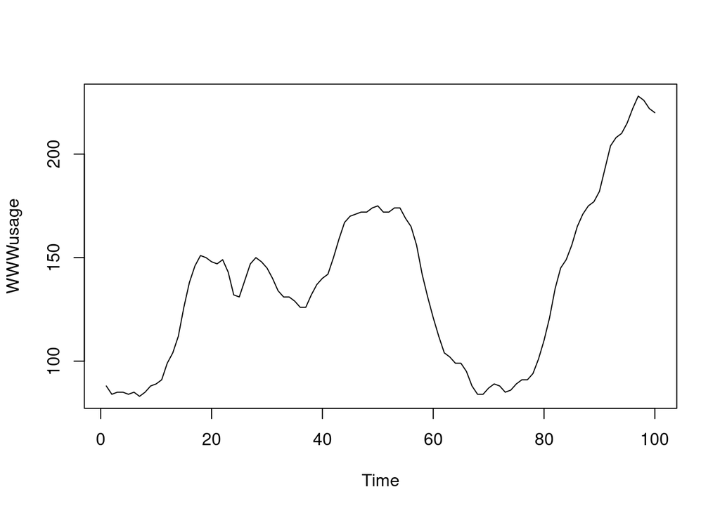

```r
plot(WWWusage)
```

```r
# estimate ARIMA model
# help(auto.arima)
fit <- auto.arima(WWWusage)
summary(fit)
```

```
## Series: WWWusage
## ARIMA(1,1,1)
##
## Coefficients:
##          ar1     ma1
##       0.6504  0.5256
## s.e.  0.0842  0.0896
##
## sigma^2 = 9.995:  log likelihood = -254.15
## AIC=514.3   AICc=514.55   BIC=522.08
##
## Training set error measures:
##                     ME     RMSE      MAE       MPE     MAPE      MASE
## Training set 0.3035616 3.113754 2.405275 0.2805566 1.917463 0.5315228
##                     ACF1
## Training set -0.01715517
```

```r
# Information criteria
AIC(fit)
```

```
## [1] 514.2995
```

```r
BIC(fit)
```

```
## [1] 522.0848
```

```r
# forecast
#help(forecast)
forecast(fit, h = 1)   #  1 period  ahead
```

```
##     Point Forecast    Lo 80    Hi 80   Lo 95   Hi 95
## 101       218.8805 214.8288 222.9322 212.684 225.077
```

```r
forecast(fit, h = 10)  # 10 periods ahead
```

```
##     Point Forecast    Lo 80    Hi 80    Lo 95    Hi 95
## 101       218.8805 214.8288 222.9322 212.6840 225.0770
## 102       218.1524 208.4496 227.8552 203.3133 232.9915
## 103       217.6789 202.3128 233.0449 194.1786 241.1792
## 104       217.3709 196.6302 238.1115 185.6508 249.0910
## 105       217.1706 191.4321 242.9091 177.8069 256.5343
## 106       217.0403 186.6844 247.3962 170.6149 263.4657
## 107       216.9556 182.3341 251.5771 164.0066 269.9046
## 108       216.9005 178.3266 255.4744 157.9068 275.8942
## 109       216.8646 174.6121 259.1172 152.2449 281.4844
## 110       216.8413 171.1478 262.5348 146.9592 286.7235
```

```r
# fit with defined ARIMA(p,d,q) order
fit2 <- Arima(WWWusage, order = c(1,1,1))
summary(fit2)
```

```
## Series: WWWusage
## ARIMA(1,1,1)
##
## Coefficients:
##          ar1     ma1
##       0.6504  0.5256
## s.e.  0.0842  0.0896
##
## sigma^2 = 9.995:  log likelihood = -254.15
## AIC=514.3   AICc=514.55   BIC=522.08
##
## Training set error measures:
##                     ME     RMSE      MAE       MPE     MAPE      MASE
## Training set 0.3035616 3.113754 2.405275 0.2805566 1.917463 0.5315228
##                     ACF1
## Training set -0.01715517
```

```r
# ARIMA order taken from another model
fit.order <- arimaorder(fit)
fit2 <- Arima(WWWusage, order = fit.order)
summary(fit2)
```

```
## Series: WWWusage
## ARIMA(1,1,1)
##
## Coefficients:
##          ar1     ma1
##       0.6504  0.5256
## s.e.  0.0842  0.0896
##
## sigma^2 = 9.995:  log likelihood = -254.15
## AIC=514.3   AICc=514.55   BIC=522.08
##
## Training set error measures:
##                     ME     RMSE      MAE       MPE     MAPE      MASE
## Training set 0.3035616 3.113754 2.405275 0.2805566 1.917463 0.5315228
##                     ACF1
## Training set -0.01715517
```

```r
# making a time series: cutting the data off at period 60 to test our model
WWWusage.60 <- WWWusage[1:60]
class(WWWusage.60)
```

```
## [1] "numeric"
```

```r
WWWusage.60 <- ts(WWWusage.60)
class(WWWusage.60)
```

```
## [1] "ts"
```

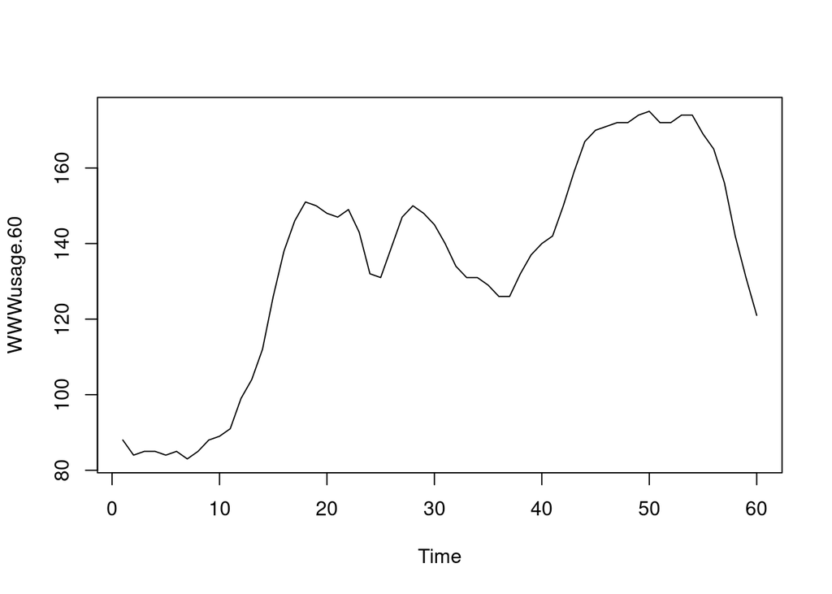

```r
plot(WWWusage.60)
```

```r
# Subset estimation and forecast
fit.60 <- auto.arima(WWWusage.60)
arimaorder(fit.60)
```

```
## p d q
## 1 1 1
```

```r
summary(fit.60)
```

```
## Series: WWWusage.60
## ARIMA(1,1,1)
##
## Coefficients:
##          ar1     ma1
##       0.6054  0.5446
## s.e.  0.1193  0.1151
##
## sigma^2 = 11.02:  log likelihood = -154.17
## AIC=314.34   AICc=314.78   BIC=320.58
##
## Training set error measures:
##                      ME     RMSE      MAE      MPE     MAPE      MASE
## Training set 0.06829842 3.235115 2.429308 0.130671 1.916921 0.5710327
##                      ACF1
## Training set -0.008853645
```

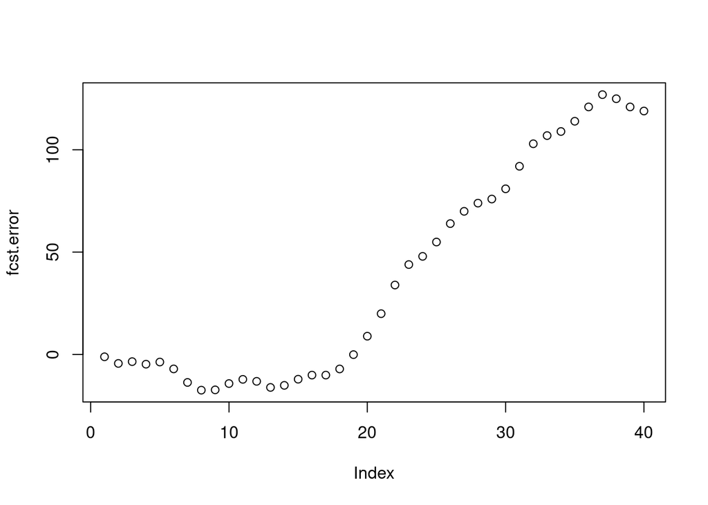

```r
fcst.60 <- forecast(fit.60, h = 40)
WWWusage.40 <- ts(WWWusage[61:100]) # generate the serties with 40 observations we dropped
fcstvalues <- fcst.60$mean  # use model to forecast forty periods ahead

# forecast errors
fcst.error <- as.numeric(WWWusage.40) - as.numeric(fcstvalues)
plot(fcst.error) # does well for the first 20 or so time periods but performs poorly thereafter.
```

## 10.2 VAR

The video that accompanies this example is here: https://www.youtube.com/watch?v=Q-9YLQXA5J0&list=PLCzsA9hMKGoaSukVTfFzzTn38IcYSjSGq&index=9

```r
#install.packages("vars")
library(vars)

data(Canada)
summary(Canada)
```

```
##        e              prod             rw              U
##  Min.   :928.6   Min.   :401.3   Min.   :386.1   Min.   : 6.700
##  1st Qu.:935.4   1st Qu.:404.8   1st Qu.:423.9   1st Qu.: 7.782
##  Median :946.0   Median :406.5   Median :444.4   Median : 9.450
##  Mean   :944.3   Mean   :407.8   Mean   :440.8   Mean   : 9.321
##  3rd Qu.:950.0   3rd Qu.:410.7   3rd Qu.:461.1   3rd Qu.:10.607
##  Max.   :961.8   Max.   :418.0   Max.   :470.0   Max.   :12.770
```

```r
# VAR --- reduced-form model --- only lags
summary(VAR(Canada, type = "none"))
```

```
##
## VAR Estimation Results:
## =========================
## Endogenous variables: e, prod, rw, U
## Deterministic variables: none
## Sample size: 83
## Log Likelihood: -221.791
## Roots of the characteristic polynomial:
##     1 0.9855 0.947 0.947
## Call:
## VAR(y = Canada, type = "none")
##
##
## Estimation results for equation e:
## ==================================
## e = e.l1 + prod.l1 + rw.l1 + U.l1
##
##         Estimate Std. Error t value Pr(>|t|)
## e.l1    0.928969   0.012815  72.490  < 2e-16 ***
## prod.l1 0.158180   0.028407   5.568 3.42e-07 ***
## rw.l1   0.005977   0.003003   1.990    0.050 .
## U.l1    0.034292   0.034759   0.987    0.327
## ---
## Signif. codes:  0 '***' 0.001 '**' 0.01 '*' 0.05 '.' 0.1 ' ' 1
##
##
## Residual standard error: 0.5038 on 79 degrees of freedom
## Multiple R-Squared:     1,   Adjusted R-squared:     1
## F-statistic: 7.292e+07 on 4 and 79 DF,  p-value: < 2.2e-16
##
##
## Estimation results for equation prod:
## =====================================
## prod = e.l1 + prod.l1 + rw.l1 + U.l1
##
##          Estimate Std. Error t value Pr(>|t|)
## e.l1    -0.016480   0.017581  -0.937   0.3514
## prod.l1  1.025370   0.038972  26.310   <2e-16 ***
## rw.l1    0.009714   0.004120   2.358   0.0208 *
## U.l1     0.115438   0.047686   2.421   0.0178 *
```

[output cut: 44 more lines]

```
##
##
## Covariance matrix of residuals:
##             e     prod       rw        U
## e     0.25382  0.06367 -0.10323 -0.16452
## prod  0.06367  0.47773  0.02516 -0.03966
## rw   -0.10323  0.02516  0.61502  0.08145
## U    -0.16452 -0.03966  0.08145  0.15210
##
## Correlation matrix of residuals:
##            e     prod       rw       U
## e     1.0000  0.18285 -0.26127 -0.8373
## prod  0.1829  1.00000  0.04641 -0.1471
## rw   -0.2613  0.04641  1.00000  0.2663
## U    -0.8373 -0.14713  0.26630  1.0000
```

```r
VAR(Canada, p = 1, type = "const")
```

```
##
## VAR Estimation Results:
## =======================
##
## Estimated coefficients for equation e:
## ======================================
## Call:
## e = e.l1 + prod.l1 + rw.l1 + U.l1 + const
##
##          e.l1       prod.l1         rw.l1          U.l1         const
##    1.17353629    0.14479389   -0.07904568    0.52438144 -192.56360758
##
##
## Estimated coefficients for equation prod:
## =========================================
## Call:
## prod = e.l1 + prod.l1 + rw.l1 + U.l1 + const
##
##         e.l1      prod.l1        rw.l1         U.l1        const
##   0.08709510   1.01970070  -0.02629309   0.32299246 -81.55109611
##
##
## Estimated coefficients for equation rw:
## =======================================
## Call:
## rw = e.l1 + prod.l1 + rw.l1 + U.l1 + const
##
##        e.l1     prod.l1       rw.l1        U.l1       const
##  0.06381103 -0.13551199  0.96872851 -0.19538479 11.61375726
##
##
## Estimated coefficients for equation U:
## ======================================
## Call:
## U = e.l1 + prod.l1 + rw.l1 + U.l1 + const
##
##         e.l1      prod.l1        rw.l1         U.l1        const
##  -0.19293575  -0.08086896   0.07538624   0.47530976 186.80892410
```

```r
VAR(Canada, p = 1, type = "trend")
```

```
##
## VAR Estimation Results:
## =======================
##
## Estimated coefficients for equation e:
## ======================================
## Call:
## e = e.l1 + prod.l1 + rw.l1 + U.l1 + trend
##
##          e.l1       prod.l1         rw.l1          U.l1         trend
##  9.288709e-01  1.583047e-01  6.086512e-03  3.402240e-02 -9.062161e-05
##
##
## Estimated coefficients for equation prod:
## =========================================
## Call:
## prod = e.l1 + prod.l1 + rw.l1 + U.l1 + trend
##
##        e.l1     prod.l1       rw.l1        U.l1       trend
##  0.03097827  0.96525456 -0.04339718  0.24540974  0.04376684
##
##
## Estimated coefficients for equation rw:
## =======================================
## Call:
## rw = e.l1 + prod.l1 + rw.l1 + U.l1 + trend
##
##        e.l1     prod.l1       rw.l1        U.l1       trend
##  0.13027992 -0.20183190  0.90572108 -0.02418632  0.04769633
##
##
## Estimated coefficients for equation U:
## ======================================
## Call:
## U = e.l1 + prod.l1 + rw.l1 + U.l1 + trend
##
##         e.l1      prod.l1        rw.l1         U.l1        trend
##  0.040722421 -0.089294909 -0.003066119  0.940893941 -0.003320148
```

```r
summary(VAR(Canada, p = 1, type = "both"))
```

```
##
## VAR Estimation Results:
## =========================
## Endogenous variables: e, prod, rw, U
## Deterministic variables: both
## Sample size: 83
## Log Likelihood: -207.525
## Roots of the characteristic polynomial:
## 0.9504 0.9504 0.9045 0.7513
## Call:
## VAR(y = Canada, p = 1, type = "both")
##
##
## Estimation results for equation e:
## ==================================
## e = e.l1 + prod.l1 + rw.l1 + U.l1 + const + trend
##
##           Estimate Std. Error t value Pr(>|t|)
## e.l1       1.23892    0.08632  14.353  < 2e-16 ***
## prod.l1    0.19465    0.03612   5.389 7.49e-07 ***
## rw.l1     -0.06776    0.02828  -2.396 0.018991 *
## U.l1       0.62301    0.16927   3.681 0.000430 ***
## const   -278.76121   75.18295  -3.708 0.000392 ***
## trend     -0.04066    0.01970  -2.064 0.042378 *
## ---
## Signif. codes:  0 '***' 0.001 '**' 0.01 '*' 0.05 '.' 0.1 ' ' 1
##
##
## Residual standard error: 0.4701 on 77 degrees of freedom
## Multiple R-Squared: 0.9975,  Adjusted R-squared: 0.9973
## F-statistic:  6088 on 5 and 77 DF,  p-value: < 2.2e-16
##
##
## Estimation results for equation prod:
## =====================================
## prod = e.l1 + prod.l1 + rw.l1 + U.l1 + const + trend
##
##          Estimate Std. Error t value Pr(>|t|)
## e.l1      0.01291    0.12583   0.103    0.919
## prod.l1   0.96314    0.05266  18.291   <2e-16 ***
```

[output cut: 52 more lines]

```
##
##
## Covariance matrix of residuals:
##             e      prod        rw        U
## e     0.22096  0.067667 -0.082793 -0.13200
## prod  0.06767  0.469517  0.002141 -0.04128
## rw   -0.08279  0.002141  0.593174  0.06374
## U    -0.13200 -0.041280  0.063738  0.12161
##
## Correlation matrix of residuals:
##            e      prod        rw       U
## e     1.0000  0.210085 -0.228688 -0.8052
## prod  0.2101  1.000000  0.004057 -0.1728
## rw   -0.2287  0.004057  1.000000  0.2373
## U    -0.8052 -0.172753  0.237307  1.0000
```